# Supporting information for "Full vector low-temperature magnetic measurements of geologic materials"

# Introduction

This IPython notebook contains data analysis associated with the paper:

> **Full vector low-temperature magnetic measurements of geologic materials** ￼

> Joshua M. Feinberg $^1$, Peter A. Solheid $^1$, Nicholas L. Swanson-Hysell $^{1,2}$, Mike Jackson $^1$ and Julie A. Bowles $^{1,3}$

> $^1$Institute for Rock Magnetism, University of Minnesota, Minneapolis, MN, USA; $^2$Department of Earth and Planetary Science, University of California, Berkeley CA, USA; $^3$Department of Geosciences, University of Wisconsin, Milwaukee, WI, USA

This notebook is part of the paper's supporting online materials and is available at https://github.com/Swanson-Hysell/2014_Feinberg-et-al_LowT along with the necessary files to execute the code. Within this github repository are the following folders:

1. Code This folder contains this notebook file as well as necessary non-standard function libraries.
2. Data This folder contains the data generated for the case studies presented in this work that are used in the data analysis and presented in the paper.
3. Manuscript This folder contains the paper text and figures.

If you are viewing this supporting material as a PDF document and want to run the code in the notebook you will need to download the code from the Github repository and you will also need a Python distribution that includes IPython and the other standard scientific python libraries. There are good instructions for installing IPython/jupyter here: http://ipython.org/install.html. Alternatively you can view the notebook online with the jupyter nbviewer at this link: https://nbviewer.jupyter.org/github/swanson-hysell/2014_Feinberg-et-al_low-temp/blob/master/Code/LowT_Data_Analysis.ipynb or this shortened version: http://bit.ly/1slx6p2

Within this notebook there are data from runs on a variety of types of specimens:

- **Magnetite**: isothermal remanent magnetizations applied to a single magnetite crystal
- **Hematite**: isothermal remanent magnetization applied to a strongly foliated polycrystalline hematite sample
- **Hematite/Magnetite**: isothermal remanent magnetization applied to a Nature Company polycrystalline sample comprised of hematite and trace magnetite
- **Pyrrhotite**: isothermal remanent magnetization applied to a a single crystal of pyrrhotite
- **Coarse-grained diabase**: natural and anhysteric remanent magnetizations for samples collected from the coarse grained interior of sills from the Umkondo Large Igneous Province of Botswana

# Import needed libraries into notebook environment

The numpy, scipy, matplotlib and pandas libraries are standard libraries for scientific python (see http://www.scipy.org). The pmag and pmagplotlib libraries are part of the PmagPy project and can be obtained from that project's github repository (https://github.com/ltauxe/PmagPy). The check_updates and get_version functions of the PmagPy libraries cause errors in the interactive environment of IPython so the code below uses a slightly modified version of those libraries that is included in the Github repository for this work. There are other functions that are necessary for the interactive plotting of paleomagnetic data (some of them edited from PmagPy) that are within the IPmag.py (see https://github.com/Swanson-Hysell/PmagPy_IPython) library that is imported in the code block below.

```python
import pmag, pmagplotlib, IPmag
import numpy as np
from scipy import interpolate
import pandas as pd
from IPython.display import display, Image, display_svg, SVG
import matplotlib.pyplot as plt
%matplotlib inline
```

When the notebook is being exported into a PDF it looks much better to have the plots be in svg format rather than png. However, when viewing the notebook as rendered html it is much faster to have the plots be png files so this line will generally be commented out.

```python
#%config InlineBackend.figure_format = 'svg'
```

## Background subtraction function

As discussed in the main text and figures, subtracting the magnetization of the blank probe is a necessary aspect of the data analysis. In order to do so, let's define a function called background_subtraction() that we can use to subtract data of a blank probe run (without a loaded sample) from data experimental runs on specimens. This function uses a spline fit to the background holder data in order to interpolate data to the temperatures where measurements were taking during the sample runs. Examples of fits to background data and subsequent background subtraction are given later in this notebook.

```python
def background_sub(background_moment, background_temp,
                           measurement_moment, measurement_temp):
    """
    subtract out data from a blank run from measurement data from a sample

    This function takes data measured with the holder alone and subtracts
    it from sample measurement data by interpolating that blank run at the
    temperatures for which data were
    """
    x = background_temp
    y = background_moment
    spline = interpolate.splrep(x,y,s=0)
    xnew = measurement_temp
    background_moment_interpolated = interpolate.splev(xnew,spline,der=0)
    bsub_moment = measurement_moment - background_moment_interpolated
    return bsub_moment
```

# Polycrystalline hematite experiments

A polycrystalline hematite sample "Labrador hematite" was pulsed with a 1.2 T field to impart an isothermal remanent magentization (IRM) along the z axis which was then cycled from room temperature to ~130 K and back using the Institute for Rock Magnetism low temperature probe (IRM-LTI) in a superconducting rock magnetometer to collect full vector data. A low-temperature cycling experiment was also conducted using a Magnetic Properties Measurement System (MPMS) to collect 1-axis data.

## IRM-LTI experiment

The data from the IRM-LTI experiment (cooling and warming data separately) can be loaded into a dataframe with the first 5 rows of the dataframe displayed using the .head() function. Note that this .head() function will be used throughout this notebook in order to give a glimpse of the data without taking the space to print all of the data out. All the data files loaded into the notebook are availible in the Github repository.

```python
Labr_hem_cooling = pd.read_csv('../Data/Labr_hematite/Labr_hem_cooling.csv')
Labr_hem_warming = pd.read_csv('../Data/Labr_hematite/Labr_hem_warming.csv')
Labr_hem_warming.head()
```

|  | specimen | Mx[Am2] | My[Am2] | Mz[Am2] | MN[Am2] | ME[Am2] | MV[Am2] | Mtot[Am2] | Dec[deg] | Inc[deg] | ... | time | series | position[cm] | Drift_ratio | Ja/Jr | run# | Description | Meas_T[K] | Mode | Type |
| --- | --- | --- | --- | --- | --- | --- | --- | --- | --- | --- | --- | --- | --- | --- | --- | --- | --- | --- | --- | --- | --- |
| 0 | Labrador hematite 02a | -7.398300e-08 | -1.075430e-08 | -0 | -0 | -1.075430e-08 | 7.398300e-08 | 0.000000 | 181.371 | 9.34415 | ... | 1:25:55 PM | 1 | NaN | NaN | 0 | NaN | NaN | 128 | DISCRETE | NaN |
| 1 | Labrador hematite 02a | -7.496650e-08 | -2.935900e-09 | -0 | -0 | -2.935900e-09 | 7.496650e-08 | 0.000000 | 180.373 | 9.44262 | ... | 1:33:42 PM | 1 | NaN | NaN | 0 | NaN | NaN | 133 | DISCRETE | NaN |
| 2 | Labrador hematite 02a | -7.558250e-08 | -1.850900e-09 | -0 | -0 | -1.850900e-09 | 7.558250e-08 | 0.000000 | 180.238 | 9.62523 | ... | 1:42:26 PM | 1 | NaN | NaN | 0 | NaN | NaN | 139 | DISCRETE | NaN |
| 3 | Labrador hematite 02a | -7.607250e-08 | -1.196550e-09 | -0 | -0 | -1.196550e-09 | 7.607250e-08 | 0.000000 | 180.155 | 9.77792 | ... | 1:48:29 PM | 1 | NaN | NaN | 0 | NaN | NaN | 143 | DISCRETE | NaN |
| 4 | Labrador hematite 02a | -8.034000e-08 | -2.277900e-09 | -0 | -0 | -2.277900e-09 | 8.034000e-08 | 0.000001 | 180.264 | 9.23522 | ... | 1:55:15 PM | 1 | NaN | NaN | 0 | NaN | NaN | 148 | DISCRETE | NaN |

5 rows × 35 columns

During the warming portion of the experiment one of the data points was collected during a flux jump on the SRM that was noted by the analyzer at the time and therefore has 'flux jump' in the 'Description' column. This point should be removed from the dataframe.

```python
Labr_hem_warming = Labr_hem_warming[Labr_hem_warming['Description'] != 'flux jump']
Labr_hem_warming.reset_index(inplace=True)
```

The M$_x$, M$_y$, M$_z$, M$_{total}$ values can be plotted as a function of temperature for this experiment showing the pronounced loss of remenance associated with cooling through hematite's Morin transition.

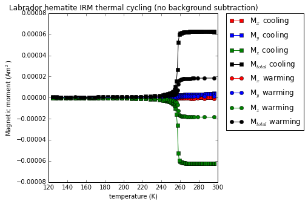

```python
plt.figure(figsize=(5,5))
plt.plot(Labr_hem_cooling['Meas_T[K]'], Labr_hem_cooling['Mx[Am2]'],
         'rs-',label='M$_x$ cooling')
plt.plot(Labr_hem_cooling['Meas_T[K]'], Labr_hem_cooling['My[Am2]'],
         'bs-',label='M$_y$ cooling')
plt.plot(Labr_hem_cooling['Meas_T[K]'], Labr_hem_cooling['Mz[Am2]'],
         'gs-',label='M$_z$ cooling')
plt.plot(Labr_hem_cooling['Meas_T[K]'], Labr_hem_cooling['Mtot[Am2]'],
         'ks-',label='M$_{total}$ cooling')
plt.plot(Labr_hem_warming['Meas_T[K]'], Labr_hem_warming['Mx[Am2]'],
         'ro-',label='M$_x$ warming')
plt.plot(Labr_hem_warming['Meas_T[K]'], Labr_hem_warming['My[Am2]'],
         'bo-',label='M$_y$ warming')
plt.plot(Labr_hem_warming['Meas_T[K]'], Labr_hem_warming['Mz[Am2]'],
         'go-',label='M$_z$ warming')
plt.plot(Labr_hem_warming['Meas_T[K]'], Labr_hem_warming['Mtot[Am2]'],
         'ko-',label='M$_{total}$ warming')
plt.legend(bbox_to_anchor=(1.05, 1), loc=2, borderaxespad=0.)
plt.xlabel('temperature (K)')
plt.ylabel('Magnetic moment (Am$^2$)')
plt.title('Labrador hematite IRM thermal cycling (no background subtraction)')
plt.show()
```

### Background subtraction

These data need to have the background subtracted from them. We will use a run of the blank probe without a loaded sample that was conducted on 04/28/2010. Data from that blank run is imported into dataframes and plotted below.

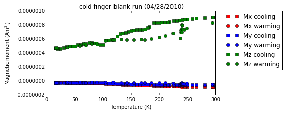

```python
blank_hem_data_cooling = pd.read_csv('../Data/Labr_hematite/20100428_blank_cooling.csv')
blank_hem_data_warming = pd.read_csv('../Data/Labr_hematite/20100428_blank_warming.csv')

fignum=1
plt.figure(num=fignum,figsize=(6,3))
plt.plot(blank_hem_data_cooling['Meas_T[K]'], blank_hem_data_cooling['Mx[Am2]'], 'rs',
         label='Mx cooling')
plt.plot(blank_hem_data_warming['Meas_T[K]'], blank_hem_data_warming['Mx[Am2]'], 'ro',
         label='Mx warming')
plt.plot(blank_hem_data_cooling['Meas_T[K]'], blank_hem_data_cooling['My[Am2]'], 'bs',
         label='My cooling')
plt.plot(blank_hem_data_warming['Meas_T[K]'], blank_hem_data_warming['My[Am2]'], 'bo',
         label='My warming')
plt.plot(blank_hem_data_cooling['Meas_T[K]'], blank_hem_data_cooling['Mz[Am2]'], 'gs',
         label='Mz cooling')
plt.plot(blank_hem_data_warming['Meas_T[K]'], blank_hem_data_warming['Mz[Am2]'], 'go',
         label='Mz warming')

plt.ylabel('Magnetic moment (Am$^2$)')
plt.xlabel('Temperature (K)')
plt.legend(bbox_to_anchor=(1.05, 1), loc=2, borderaxespad=0.)
plt.title('cold finger blank run (04/28/2010)')
plt.show()
```

The background_subtraction() function can be used to subtract the interpolation of data from this cold finger blank run from the measured data during the low-temperature cycling experiment on the hematite. Given that the magnetization of the cold finger looks to be more or less reversible with temperature and that there is better resolution (without a gap between 250 and 300 K) for the cooling curve, the cooling curve will be used for the background subtraction.

```python
#For the interpolate function within the background_subtraction function to
#work, the x values (temperature) need to be sorted to be ascending.
blank_hem_data_cooling = blank_hem_data_cooling.sort(['Meas_T[K]'])

Mx_cooling_bsub = background_sub(blank_hem_data_cooling['Mx[Am2]'],
                                 blank_hem_data_cooling['Meas_T[K]'],
                                 Labr_hem_cooling['Mx[Am2]'],
                                 Labr_hem_cooling['Meas_T[K]'])

My_cooling_bsub = background_sub(blank_hem_data_cooling['My[Am2]'],
                                 blank_hem_data_cooling['Meas_T[K]'],
                                 Labr_hem_cooling['My[Am2]'],
                                 Labr_hem_cooling['Meas_T[K]'])

Mz_cooling_bsub = background_sub(blank_hem_data_cooling['Mz[Am2]'],
                                 blank_hem_data_cooling['Meas_T[K]'],
                                 Labr_hem_cooling['Mz[Am2]'],
                                 Labr_hem_cooling['Meas_T[K]'])

Mx_warming_bsub = background_sub(blank_hem_data_cooling['Mx[Am2]'],
                                 blank_hem_data_cooling['Meas_T[K]'],
                                 Labr_hem_warming['Mx[Am2]'],
                                 Labr_hem_warming['Meas_T[K]'])

My_warming_bsub = background_sub(blank_hem_data_cooling['My[Am2]'],
                                 blank_hem_data_cooling['Meas_T[K]'],
                                 Labr_hem_warming['My[Am2]'],
                                 Labr_hem_warming['Meas_T[K]'])

Mz_warming_bsub = background_sub(blank_hem_data_cooling['Mz[Am2]'],
                                 blank_hem_data_cooling['Meas_T[K]'],
                                 Labr_hem_warming['Mz[Am2]'],
                                 Labr_hem_warming['Meas_T[K]'])

#calculate the full vector after background subtraction
Mtotal_cooling = np.sqrt(Mx_cooling_bsub**2+My_cooling_bsub**2+Mz_cooling_bsub**2)
Mtotal_warming = np.sqrt(Mx_warming_bsub**2+My_warming_bsub**2+Mz_warming_bsub**2)
#the specimen weighs 1.0129 g to get the units into Am2/kg let's divide by 1.0129/1000
Mtotal_cooling_mass_normalized = Mtotal_cooling/(1.0129/1000)
Mtotal_warming_mass_normalized = Mtotal_warming/(1.0129/1000)
```

### Directional data

In addition to plotting the magnetization along each axis, the directions of the data can be plotted on an equal area plot. The code below generates a plot that shows the directions from throughout the low-temperature cycling both without background subtraction and with background subtraction.

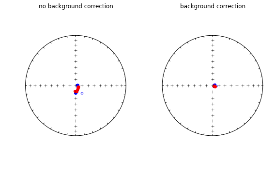

```python
directions_cooling_cart=[]
directions_warming_cart=[]

for n in range(len(Labr_hem_cooling)):
    directions_cooling_cart.append([Labr_hem_cooling['Mx[Am2]'][n],
                                    Labr_hem_cooling['My[Am2]'][n],
                                    Labr_hem_cooling['Mz[Am2]'][n]])
for n in range(len(Labr_hem_warming)):
    directions_warming_cart.append([Labr_hem_warming['Mx[Am2]'][n],
                                    Labr_hem_warming['My[Am2]'][n],
                                    Labr_hem_warming['Mz[Am2]'][n]])

directions_cooling_DI=pmag.cart2dir(directions_cooling_cart)
directions_warming_DI=pmag.cart2dir(directions_warming_cart)

directions_bsub_cooling_cart=[]
directions_bsub_warming_cart=[]

for n in range(len(Labr_hem_cooling)):
    directions_bsub_cooling_cart.append([Mx_cooling_bsub[n],
                                         My_cooling_bsub[n],
                                         Mz_cooling_bsub[n]])
for n in range(len(Labr_hem_warming)):
    directions_bsub_warming_cart.append([Mx_warming_bsub[n],
                                         My_warming_bsub[n],
                                         Mz_warming_bsub[n]])

directions_bsub_cooling_DI=pmag.cart2dir(directions_bsub_cooling_cart)
directions_bsub_warming_DI=pmag.cart2dir(directions_bsub_warming_cart)

fig=plt.figure(figsize=(8,5),dpi=160)

plt.subplot(121)
pmagplotlib.plotNET(fignum)
IPmag.iplotDI(directions_cooling_DI,'b')
IPmag.iplotDI(directions_warming_DI,'r')
plt.title('no background correction')

plt.subplot(122)
pmagplotlib.plotNET(fignum)
IPmag.iplotDI(directions_bsub_cooling_DI,'b')
IPmag.iplotDI(directions_bsub_warming_DI,'r')
plt.title('background correction')
plt.savefig('code_output/Labr_hem_eqarea.pdf')
plt.show()
```

It is clear from the above plot that the background subtraction implementation was effective in removing signal associated with the blank probe. Note that at the time of this experiment the probe was more magnetic than it is at present as there were subsequent improvements. See the main text for details.

## MPMS experiment

In addition to the 3-axis data obtained with the IRM-LTI, we obtained single axis data on the hematite sample using an MPMS. These data can be imported into a data frame.

```python
Labr_hem_MPMS = pd.read_csv('../Data/Labr_hematite/Labr_hem_MPMS.csv')
Labr_hem_MPMS.head()
```

|  | T [K] | Bapp [T] | M [Am2/kg] | reg fit | timestamp | T [K].1 | Bapp [T].1 | M [Am2/kg].1 | reg fit.1 | timestamp.1 |
| --- | --- | --- | --- | --- | --- | --- | --- | --- | --- | --- |
| 0 | 299.9905 | 0 | 0.041991 | 0.970553 | 5/7/2010 12:11:45 PM | 19.99694 | 0 | 0.001129 | 0.989705 | 5/7/10 15:18 |
| 1 | 294.3364 | 0 | 0.041716 | 0.970341 | 5/7/2010 12:15:20 PM | 25.49144 | 0 | 0.001129 | 0.989654 | 5/7/10 15:20 |
| 2 | 289.1934 | 0 | 0.041456 | 0.970064 | 5/7/2010 12:16:10 PM | 30.56160 | 0 | 0.001129 | 0.989615 | 5/7/10 15:21 |
| 3 | 284.0423 | 0 | 0.041179 | 0.969775 | 5/7/2010 12:16:56 PM | 35.57994 | 0 | 0.001128 | 0.989613 | 5/7/10 15:22 |
| 4 | 279.7256 | 0 | 0.040682 | 0.969927 | 5/7/2010 12:19:34 PM | 40.53156 | 0 | 0.001128 | 0.989653 | 5/7/10 15:23 |

## Comparision between IRM-LTI and MPMS data

As can be seen in the output of the code cell below, the magnetization measured at ~289 K (the temperature to which the plots have been normalized) for the specimen was about 33% lower on the specimen on the MPMS than on the IRM-LTI. This could be due, in part, to a portion of the magnetization being off of the one axis being measured on the MPMS although it is unlikely that a misorientation would be as great as the 48º angle that would be required for this to be the sole explanation for the difference.

```python
Labr_hem_MPMS_289 = Labr_hem_MPMS['M [Am2/kg]'][2]
Labr_hem_LTI_289 = Mtotal_cooling_mass_normalized[7]
print 'At this temperature (K):'
print Labr_hem_MPMS['T [K]'][2]
print 'The magnetization of the hematite sample on the MPMS is (Am2/kg):'
print Labr_hem_MPMS_289
print ''
print 'At this temperature (K):'
print Labr_hem_cooling['Meas_T[K]'][7]
print 'The magnetization of the hematite sample on the IRM-LTI is (Am2/kg):'
print Labr_hem_LTI_289
print ""
print 'The percentage difference between the magnetizations is:'
print ((Labr_hem_LTI_289-Labr_hem_MPMS_289)/Labr_hem_LTI_289)*100
```

```
At this temperature (K):
289.1934
The magnetization of the hematite sample on the MPMS is (Am2/kg):
0.041456254

At this temperature (K):
289.0
The magnetization of the hematite sample on the IRM-LTI is (Am2/kg):
0.0622871852112

The percentage difference between the magnetizations is:
33.4433658232
```

Let's make a plot where the MPMS and LTI data are normalized so that they can be directly compared.

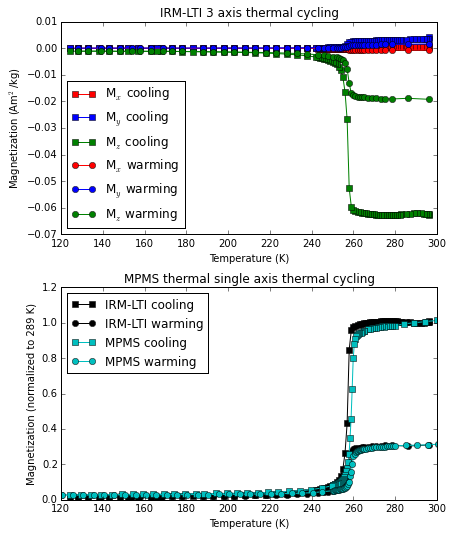

```python
adjustprops = dict(left=0.1, bottom=0.1, right=0.97, top=0.93, wspace=0.25, hspace=0.25)
fig=plt.figure(figsize=(6,8),dpi=160)
fig.subplots_adjust(**adjustprops)
ax1 = plt.subplot(211)

ax1.plot(Labr_hem_cooling['Meas_T[K]'], Mx_cooling_bsub/(1.0129/1000),
         'rs-',label='M$_x$ cooling')
ax1.plot(Labr_hem_cooling['Meas_T[K]'], My_cooling_bsub/(1.0129/1000),
         'bs-',label='M$_y$ cooling')
ax1.plot(Labr_hem_cooling['Meas_T[K]'], Mz_cooling_bsub/(1.0129/1000),
         'gs-',label='M$_z$ cooling')
ax1.plot(Labr_hem_warming['Meas_T[K]'], Mx_warming_bsub/(1.0129/1000),
         'ro-',label='M$_x$ warming')
ax1.plot(Labr_hem_warming['Meas_T[K]'], My_warming_bsub/(1.0129/1000),
         'bo-',label='M$_y$ warming')
ax1.plot(Labr_hem_warming['Meas_T[K]'], Mz_warming_bsub/(1.0129/1000),
         'go-',label='M$_z$ warming')
plt.legend(loc=3)
plt.title('IRM-LTI 3 axis thermal cycling')
plt.xlabel('Temperature (K)')
plt.ylabel('Magnetization (Am$^2$/kg)')

ax2 = plt.subplot(212)
ax2.plot(Labr_hem_cooling['Meas_T[K]'],Mtotal_cooling_mass_normalized/Labr_hem_LTI_289,
         'ks-', label='IRM-LTI cooling')
ax2.plot(Labr_hem_warming['Meas_T[K]'],Mtotal_warming_mass_normalized/Labr_hem_LTI_289,
         'ko-', label='IRM-LTI warming')
ax2.plot(Labr_hem_MPMS['T [K]'],Labr_hem_MPMS['M [Am2/kg]']/Labr_hem_MPMS_289,
         'cs-', label='MPMS cooling')
ax2.plot(Labr_hem_MPMS['T [K].1'],Labr_hem_MPMS['M [Am2/kg].1']/Labr_hem_MPMS_289,
         'co-', label='MPMS warming')
plt.xlim(120, 300)
plt.ylim(ymin=0)
plt.title('MPMS thermal single axis thermal cycling')
plt.xlabel('Temperature (K)')
plt.ylabel('Magnetization (normalized to 289 K)')
plt.legend(loc=2)
plt.savefig('code_output/Labr_hem_data.pdf')
plt.show()
```

### Estimating the Morin transition

There looks to be a slight temperature difference between loss of remanence observed using the IRM-LTI and the MPMS. This difference can be see more clearly in the gradient of the low-temperature cycling data. These gradient data can then be used to make estimates of the Morin transition temperature with each method to quantify the magnitude of this temperature difference.

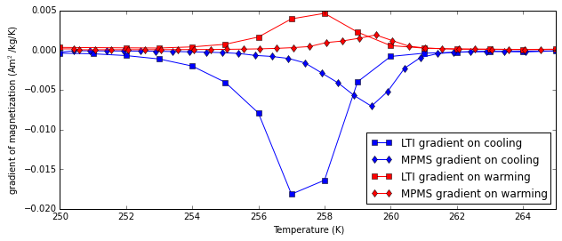

```python
gradient_LTI_cooling = np.gradient(Mtotal_cooling_mass_normalized)
gradient_MPMS_cooling = np.gradient(Labr_hem_MPMS['M [Am2/kg]'][0:94])
gradient_LTI_warming = np.gradient(Mtotal_warming_mass_normalized)
gradient_MPMS_warming = np.gradient(Labr_hem_MPMS['M [Am2/kg].1'])

fig=plt.figure(figsize=(10,4))
plt.plot(Labr_hem_cooling['Meas_T[K]'], gradient_LTI_cooling,
         'bs-',label='LTI gradient on cooling')
plt.plot(Labr_hem_MPMS['T [K]'][0:94],gradient_MPMS_cooling,
         'bd-', label='MPMS gradient on cooling')
plt.plot(Labr_hem_warming['Meas_T[K]'], gradient_LTI_warming,
         'rs-',label='LTI gradient on warming')
plt.plot(Labr_hem_MPMS['T [K].1'],gradient_MPMS_warming,
         'rd-', label='MPMS gradient on warming')
plt.xlim(250, 265)
plt.xlabel('Temperature (K)')
plt.ylabel('gradient of magnetization (Am$^2$/kg/K)')
plt.legend(loc=4)
plt.show()
```

To estimate the Morin temperature using these data, let's fit cubic splines to the data. For comparision of the warming and cooling data the negative of the gradient upon warming will be calculated and plotted. The plot compares the data points themselves with the interpolated spline fit.

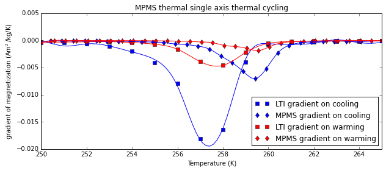

```python
from scipy.interpolate import interp1d

#interpolate the data using a cubic spline
f_LTI_cooling_inter =  interp1d(Labr_hem_cooling['Meas_T[K]'], gradient_LTI_cooling,
                                kind='cubic')
f_MPMS_cooling_inter = interp1d(Labr_hem_MPMS['T [K]'][0:94], gradient_MPMS_cooling,
                                kind='cubic')
f_LTI_warming_inter =  interp1d(Labr_hem_warming['Meas_T[K]'], -gradient_LTI_warming,
                                kind='cubic')
f_MPMS_warming_inter = interp1d(Labr_hem_MPMS['T [K].1'], -gradient_MPMS_warming,
                                kind='cubic')

xnew = np.linspace(250,265,100)

gradient_MPMS_cooling_interpolated = f_MPMS_cooling_inter(xnew)
gradient_LTI_cooling_interpolated = f_LTI_cooling_inter(xnew)
gradient_MPMS_warming_interpolated = f_MPMS_warming_inter(xnew)
gradient_LTI_warming_interpolated = f_LTI_warming_inter(xnew)

fig=plt.figure(figsize=(10,4))
plt.plot(Labr_hem_cooling['Meas_T[K]'],gradient_LTI_cooling,
         'bs',label='LTI gradient on cooling')
plt.plot(Labr_hem_MPMS['T [K]'][0:94],gradient_MPMS_cooling,
         'bd', label='MPMS gradient on cooling')
plt.plot(Labr_hem_warming['Meas_T[K]'],-gradient_LTI_warming,
         'rs',label='LTI gradient on warming')
plt.plot(Labr_hem_MPMS['T [K].1'],-gradient_MPMS_warming,
         'rd', label='MPMS gradient on warming')
plt.xlim(250, 265)
plt.title('MPMS thermal single axis thermal cycling')
plt.xlabel('Temperature (K)')
plt.ylabel('gradient of magnetization (Am$^2$/kg/K)')
plt.legend(loc=4)

plt.plot(xnew, gradient_MPMS_cooling_interpolated, 'b-')
plt.plot(xnew, gradient_LTI_cooling_interpolated, 'b-')
plt.plot(xnew, gradient_MPMS_warming_interpolated, 'r-')
plt.plot(xnew, gradient_LTI_warming_interpolated, 'r-')
plt.show()
```

The downhill simplex algorithm as implemented in scipy.optimize can be used to find the peak of the interpolated data. This peak is the estimate of the Morin transition temperature.

```python
from scipy.optimize import fmin
gradient_LTI_cooling_min = fmin(f_LTI_cooling_inter, x0=257)
print 'The peak gradient for LTI cooling is at: ' + str(gradient_LTI_cooling_min)
print ""
gradient_MPMS_cooling_min = fmin(f_MPMS_cooling_inter, x0=259)
print 'The peak gradient for MPMS cooling is at: ' + str(gradient_MPMS_cooling_min)
print ""
gradient_LTI_warming_min = fmin(f_LTI_warming_inter, x0=257)
print 'The peak gradient for LTI warming is at: ' + str(gradient_LTI_warming_min)
print ""
gradient_MPMS_warming_min = fmin(f_MPMS_warming_inter, x0=259)
print 'The peak gradient for MPMS warming is at: ' + str(gradient_MPMS_warming_min)
```

```
Optimization terminated successfully.
         Current function value: -0.019496
         Iterations: 18
         Function evaluations: 36
The peak gradient for LTI cooling is at: [ 257.37332764]

Optimization terminated successfully.
         Current function value: -0.007081
         Iterations: 18
         Function evaluations: 37
The peak gradient for MPMS cooling is at: [ 259.39302902]

Optimization terminated successfully.
         Current function value: -0.004769
         Iterations: 18
         Function evaluations: 36
The peak gradient for LTI warming is at: [ 257.7300869]

Optimization terminated successfully.
         Current function value: -0.001900
         Iterations: 18
         Function evaluations: 37
The peak gradient for MPMS warming is at: [ 259.51168861]
```

Given that the magnitude of the transition is greater upon cooling, we use the Morin transition temperature estimates from the cooling curves in the main text of the paper where we note that there is a 2 degree difference between the Morin transition temperature was estimated using the IRM-LTI (257.4 K) in comparision to the MPMS (259.4 K).

# Single crystal magnetite experiments

## IRM-LTI experiments

A specimen cut from single crystal magnetite octahedron (IKON magnetite) underwent a series of experiments where IRM magnetizations were applied along different axes and then cycled to low temperature using the IRM-LTI.

- Series 1 experiment was designed to apply an IRM along the $<111>$
- Series 2 experiment was designed to apply an IRM along the $<100>$ "SIRM 1.2T (350 Volt pulse) along 100 (along Z)"
- Series 3 experiment was designed to apply the magnetization along the $<110>$

A schematic drawing of the specimen and its orientation relative to the measurement axes of the superconducting rock magnetometer (SRM) and to the orientations of three separate 1.2 T IRMs is shown below.

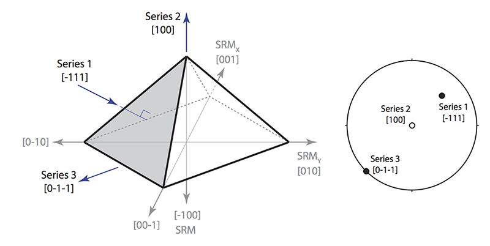

```python
Image(filename=('../Data/Ikon_magnetite/experiment_schematic.png'))
```

The data from these experiments can be imported into data frames.

```python
Ikon_series1_cooling = pd.read_csv('../Data/Ikon_magnetite/Ikon_mag_series1_cooling.csv')
Ikon_series1_warming = pd.read_csv('../Data/Ikon_magnetite/Ikon_mag_series1_warming.csv')

Ikon_series2_cooling = pd.read_csv('../Data/Ikon_magnetite/Ikon_mag_series2_cooling.csv')
Ikon_series2_warming = pd.read_csv('../Data/Ikon_magnetite/Ikon_mag_series2_warming.csv')

Ikon_series3_cooling = pd.read_csv('../Data/Ikon_magnetite/Ikon_mag_series3_cooling.csv')
Ikon_series3_warming = pd.read_csv('../Data/Ikon_magnetite/Ikon_mag_series3_warming.csv')
```

### Background subtraction

The blank holder data used for the background correction of the Labrador hematite sample will also be used to the background correction for these experiments as these data were collected in the same interval of time that the instrument was in use.

```python
#For the interpolate function to work the x values (temperature) need to be ascending.
#The blank_hem_data_cooling can be sorted so that temperatures are ascending
blank_hem_data_cooling = blank_hem_data_cooling.sort(['Meas_T[K]'])

Ikon_series1_cooling['Mx_bsub[Am2]'] = background_sub(blank_hem_data_cooling['Mx[Am2]'],
                                                      blank_hem_data_cooling['Meas_T[K]'],
                                                      Ikon_series1_cooling['Mx[Am2]'],
                                                      Ikon_series1_cooling['Meas_T[K]'])

Ikon_series1_cooling['My_bsub[Am2]'] = background_sub(blank_hem_data_cooling['My[Am2]'],
                                                      blank_hem_data_cooling['Meas_T[K]'],
                                                      Ikon_series1_cooling['My[Am2]'],
                                                      Ikon_series1_cooling['Meas_T[K]'])

Ikon_series1_cooling['Mz_bsub[Am2]'] = background_sub(blank_hem_data_cooling['Mz[Am2]'],
                                                      blank_hem_data_cooling['Meas_T[K]'],
                                                      Ikon_series1_cooling['Mz[Am2]'],
                                                      Ikon_series1_cooling['Meas_T[K]'])

Ikon_series1_warming['Mx_bsub[Am2]'] = background_sub(blank_hem_data_cooling['Mx[Am2]'],
                                                      blank_hem_data_cooling['Meas_T[K]'],
                                                      Ikon_series1_warming['Mx[Am2]'],
                                                      Ikon_series1_warming['Meas_T[K]'])

Ikon_series1_warming['My_bsub[Am2]'] = background_sub(blank_hem_data_cooling['My[Am2]'],
                                                      blank_hem_data_cooling['Meas_T[K]'],
                                                      Ikon_series1_warming['My[Am2]'],
                                                      Ikon_series1_warming['Meas_T[K]'])

Ikon_series1_warming['Mz_bsub[Am2]'] = background_sub(blank_hem_data_cooling['Mz[Am2]'],
                                                      blank_hem_data_cooling['Meas_T[K]'],
                                                      Ikon_series1_warming['Mz[Am2]'],
                                                      Ikon_series1_warming['Meas_T[K]'])

Ikon_series2_cooling['Mx_bsub[Am2]'] = background_sub(blank_hem_data_cooling['Mx[Am2]'],
                                                      blank_hem_data_cooling['Meas_T[K]'],
                                                      Ikon_series2_cooling['Mx[Am2]'],
                                                      Ikon_series2_cooling['Meas_T[K]'])

Ikon_series2_cooling['My_bsub[Am2]'] = background_sub(blank_hem_data_cooling['My[Am2]'],
                                                      blank_hem_data_cooling['Meas_T[K]'],
                                                      Ikon_series2_cooling['My[Am2]'],
                                                      Ikon_series2_cooling['Meas_T[K]'])

Ikon_series2_cooling['Mz_bsub[Am2]'] = background_sub(blank_hem_data_cooling['Mz[Am2]'],
                                                      blank_hem_data_cooling['Meas_T[K]'],
                                                      Ikon_series2_cooling['Mz[Am2]'],
                                                      Ikon_series2_cooling['Meas_T[K]'])

Ikon_series2_warming['Mx_bsub[Am2]'] = background_sub(blank_hem_data_cooling['Mx[Am2]'],
                                                      blank_hem_data_cooling['Meas_T[K]'],
                                                      Ikon_series2_warming['Mx[Am2]'],
                                                      Ikon_series2_warming['Meas_T[K]'])

Ikon_series2_warming['My_bsub[Am2]'] = background_sub(blank_hem_data_cooling['My[Am2]'],
                                                      blank_hem_data_cooling['Meas_T[K]'],
                                                      Ikon_series2_warming['My[Am2]'],
                                                      Ikon_series2_warming['Meas_T[K]'])

Ikon_series2_warming['Mz_bsub[Am2]'] = background_sub(blank_hem_data_cooling['Mz[Am2]'],
                                                      blank_hem_data_cooling['Meas_T[K]'],
                                                      Ikon_series2_warming['Mz[Am2]'],
                                                      Ikon_series2_warming['Meas_T[K]'])

Ikon_series3_cooling['Mx_bsub[Am2]'] = background_sub(blank_hem_data_cooling['Mx[Am2]'],
                                                      blank_hem_data_cooling['Meas_T[K]'],
                                                      Ikon_series3_cooling['Mx[Am2]'],
                                                      Ikon_series3_cooling['Meas_T[K]'])

Ikon_series3_cooling['My_bsub[Am2]'] = background_sub(blank_hem_data_cooling['My[Am2]'],
                                                      blank_hem_data_cooling['Meas_T[K]'],
                                                      Ikon_series3_cooling['My[Am2]'],
                                                      Ikon_series3_cooling['Meas_T[K]'])

Ikon_series3_cooling['Mz_bsub[Am2]'] = background_sub(blank_hem_data_cooling['Mz[Am2]'],
                                                      blank_hem_data_cooling['Meas_T[K]'],
                                                      Ikon_series3_cooling['Mz[Am2]'],
                                                      Ikon_series3_cooling['Meas_T[K]'])

Ikon_series3_warming['Mx_bsub[Am2]'] = background_sub(blank_hem_data_cooling['Mx[Am2]'],
                                                      blank_hem_data_cooling['Meas_T[K]'],
                                                      Ikon_series3_warming['Mx[Am2]'],
                                                      Ikon_series3_warming['Meas_T[K]'])

Ikon_series3_warming['My_bsub[Am2]'] = background_sub(blank_hem_data_cooling['My[Am2]'],
                                                      blank_hem_data_cooling['Meas_T[K]'],
                                                      Ikon_series3_warming['My[Am2]'],
                                                      Ikon_series3_warming['Meas_T[K]'])

Ikon_series3_warming['Mz_bsub[Am2]'] = background_sub(blank_hem_data_cooling['Mz[Am2]'],
                                                      blank_hem_data_cooling['Meas_T[K]'],
                                                      Ikon_series3_warming['Mz[Am2]'],
                                                      Ikon_series3_warming['Meas_T[K]'])
```

### Total vector calculation

From these background corrected three-axis data the total vector can be calculated.

```python
Ikon_series1_cooling['Mtotal_bsub[Am2]'] = np.sqrt(Ikon_series1_cooling['Mx_bsub[Am2]']**2+
                                                   Ikon_series1_cooling['My_bsub[Am2]']**2+
                                                   Ikon_series1_cooling['Mz_bsub[Am2]']**2)
Ikon_series1_warming['Mtotal_bsub[Am2]'] = np.sqrt(Ikon_series1_warming['Mx_bsub[Am2]']**2+
                                                   Ikon_series1_warming['My_bsub[Am2]']**2+
                                                   Ikon_series1_warming['Mz_bsub[Am2]']**2)

Ikon_series2_cooling['Mtotal_bsub[Am2]'] = np.sqrt(Ikon_series2_cooling['Mx_bsub[Am2]']**2+
                                                   Ikon_series2_cooling['My_bsub[Am2]']**2+
                                                   Ikon_series2_cooling['Mz_bsub[Am2]']**2)
Ikon_series2_warming['Mtotal_bsub[Am2]'] = np.sqrt(Ikon_series2_warming['Mx_bsub[Am2]']**2+
                                                   Ikon_series2_warming['My_bsub[Am2]']**2+
                                                   Ikon_series2_warming['Mz_bsub[Am2]']**2)

Ikon_series3_cooling['Mtotal_bsub[Am2]'] = np.sqrt(Ikon_series3_cooling['Mx_bsub[Am2]']**2+
                                                   Ikon_series3_cooling['My_bsub[Am2]']**2+
                                                   Ikon_series3_cooling['Mz_bsub[Am2]']**2)
Ikon_series3_warming['Mtotal_bsub[Am2]'] = np.sqrt(Ikon_series3_warming['Mx_bsub[Am2]']**2+
                                                   Ikon_series3_warming['My_bsub[Am2]']**2+
                                                   Ikon_series3_warming['Mz_bsub[Am2]']**2)
```

### Directional and intensity plots for all three experiments

Plot the three-axis data for each experiment.

[figure not shown]

[figure not shown]

[figure not shown]

```python
plt.figure(figsize=(3,3),dpi=160)
plt.plot(Ikon_series1_cooling['Meas_T[K]'], Ikon_series1_cooling['Mx_bsub[Am2]'], 'rs-',
         label='Mx cooling')
plt.plot(Ikon_series1_cooling['Meas_T[K]'], Ikon_series1_cooling['My_bsub[Am2]'], 'bs-',
         label='My cooling')
plt.plot(Ikon_series1_cooling['Meas_T[K]'], Ikon_series1_cooling['Mz_bsub[Am2]'], 'gs-',
         label='Mz cooling')
plt.plot(Ikon_series1_warming['Meas_T[K]'], Ikon_series1_warming['Mx_bsub[Am2]'], 'ro-',
         label='Mx warming')
plt.plot(Ikon_series1_warming['Meas_T[K]'], Ikon_series1_warming['My_bsub[Am2]'], 'bo-',
         label='My warming')
plt.plot(Ikon_series1_warming['Meas_T[K]'], Ikon_series1_warming['Mz_bsub[Am2]'], 'go-',
         label='Mz warming')
plt.ylabel('Moment (x10$^{-6}$ Am$^2$)')
plt.ticklabel_format(style='sci', scilimits=(0,0), axis='y')
plt.xlabel('Temperature (K)')
plt.legend(bbox_to_anchor=(1.05, 1), loc=2, borderaxespad=0.)
plt.title('IKON magnetite (series 1 experiment)')
plt.show()

plt.figure(figsize=(3,3),dpi=160)
plt.plot(Ikon_series2_cooling['Meas_T[K]'], Ikon_series2_cooling['Mx_bsub[Am2]'], 'rs-',
         label='Mx cooling')
plt.plot(Ikon_series2_cooling['Meas_T[K]'], Ikon_series2_cooling['My_bsub[Am2]'], 'bs-',
         label='My cooling')
plt.plot(Ikon_series2_cooling['Meas_T[K]'], Ikon_series2_cooling['Mz_bsub[Am2]'], 'gs-',
         label='Mz cooling')
plt.plot(Ikon_series2_warming['Meas_T[K]'], Ikon_series2_warming['Mx_bsub[Am2]'], 'ro-',
         label='Mx warming')
plt.plot(Ikon_series2_warming['Meas_T[K]'], Ikon_series2_warming['My_bsub[Am2]'], 'bo-',
         label='My warming')
plt.plot(Ikon_series2_warming['Meas_T[K]'], Ikon_series2_warming['Mz_bsub[Am2]'], 'go-',
         label='Mz warming')
plt.ylabel('Moment (x10$^{-6}$ Am$^2$)')
plt.ticklabel_format(style='sci', scilimits=(0,0), axis='y')
plt.xlabel('Temperature (K)')
plt.legend(bbox_to_anchor=(1.05, 1), loc=2, borderaxespad=0.)
plt.title('IKON magnetite (series 2 experiment)')
plt.savefig('code_output/Ikon_magnetite_series2.pdf')
plt.show()

plt.figure(figsize=(3,3),dpi=160)
plt.plot(Ikon_series3_cooling['Meas_T[K]'], Ikon_series3_cooling['Mx_bsub[Am2]'], 'rs-',
         label='Mx cooling')
plt.plot(Ikon_series3_cooling['Meas_T[K]'], Ikon_series3_cooling['My_bsub[Am2]'], 'bs-',
         label='My cooling')
plt.plot(Ikon_series3_cooling['Meas_T[K]'], Ikon_series3_cooling['Mz_bsub[Am2]'], 'gs-',
         label='Mz cooling')
plt.plot(Ikon_series3_warming['Meas_T[K]'], Ikon_series3_warming['Mx_bsub[Am2]'], 'ro-',
         label='Mx warming')
plt.plot(Ikon_series3_warming['Meas_T[K]'], Ikon_series3_warming['My_bsub[Am2]'], 'bo-',
         label='My warming')
plt.plot(Ikon_series3_warming['Meas_T[K]'], Ikon_series3_warming['Mz_bsub[Am2]'], 'go-',
         label='Mz warming')
plt.ylabel('Moment (x10$^{-6}$ Am$^2$)')
plt.ticklabel_format(style='sci', scilimits=(0,0), axis='y')
plt.xlabel('Temperature (K)')
plt.legend(bbox_to_anchor=(1.05, 1), loc=2, borderaxespad=0.)
plt.title('IKON magnetite (series 3 experiment)')
plt.show()
```

The total moment as calculated from the 3-axis data is plotted below in a single plot that shows all three experiments.

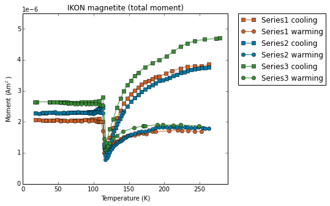

```python
plt.figure(figsize=(6,5),dpi=160)
plt.plot(Ikon_series1_cooling['Meas_T[K]'], Ikon_series1_cooling['Mtotal_bsub[Am2]'], 's-',
         label='Series1 cooling',color='#CD5F28')
plt.plot(Ikon_series1_warming['Meas_T[K]'], Ikon_series1_warming['Mtotal_bsub[Am2]'], 'o-',
         label='Series1 warming',color='#CD5F28')
plt.plot(Ikon_series2_cooling['Meas_T[K]'], Ikon_series2_cooling['Mtotal_bsub[Am2]'], 's-',
         label='Series2 cooling',color='#0077A2')
plt.plot(Ikon_series2_warming['Meas_T[K]'], Ikon_series2_warming['Mtotal_bsub[Am2]'], 'o-',
         label='Series2 warming',color='#0077A2')
plt.plot(Ikon_series3_cooling['Meas_T[K]'], Ikon_series3_cooling['Mtotal_bsub[Am2]'], 's-',
         label='Series3 cooling',color='#3B8B36')
plt.plot(Ikon_series3_warming['Meas_T[K]'], Ikon_series3_warming['Mtotal_bsub[Am2]'], 'o-',
         label='Series3 warming',color='#3B8B36')

plt.ylabel('Moment (Am$^2$)')
plt.xlabel('Temperature (K)')
plt.xlim(0, 290)
plt.ylim(0, .0000055)
plt.ticklabel_format(style='sci', scilimits=(0,0), axis='y')
plt.legend(bbox_to_anchor=(1.05, 1), loc=2, borderaxespad=0.)
plt.title('IKON magnetite (total moment)')
plt.savefig('code_output/Ikon_magnetite_total.pdf')
plt.show()
```

The remanence lost in each experiment between 260 K and just prior to the Verwey transition increase.

```python
series1_260 = Ikon_series1_cooling['Mtotal_bsub[Am2]'][0]
series2_260 = Ikon_series2_cooling['Mtotal_bsub[Am2]'][0]
series3_260 = Ikon_series3_cooling['Mtotal_bsub[Am2]'][2]
series1_min = Ikon_series1_cooling['Mtotal_bsub[Am2]'].min()
series2_min = Ikon_series2_cooling['Mtotal_bsub[Am2]'].min()
series3_min = Ikon_series3_cooling['Mtotal_bsub[Am2]'].min()
print 'Series 1 percent lost between 260K and minima'
print ((series1_260-series1_min)/series1_260)*100
print 'Series 2 percent lost between 260K and minima'
print ((series2_260-series2_min)/series2_260)*100
print 'Series 3 percent lost between 260K and minima'
print ((series3_260-series3_min)/series3_260)*100
```

```
Series 1 percent lost between 260K and minima
67.8202160088
Series 2 percent lost between 260K and minima
75.1987424572
Series 3 percent lost between 260K and minima
71.7873125177
```

The remanence lost in each experiment between 260 K and the plateau following the Verwey transition increase.

```python
series1_260 = Ikon_series1_cooling['Mtotal_bsub[Am2]'][0]
series2_260 = Ikon_series2_cooling['Mtotal_bsub[Am2]'][0]
series3_260 = Ikon_series3_cooling['Mtotal_bsub[Am2]'][2]
series1_50 = Ikon_series1_cooling['Mtotal_bsub[Am2]'][35]
series2_50 = Ikon_series2_cooling['Mtotal_bsub[Am2]'][58]
series3_50 = Ikon_series3_cooling['Mtotal_bsub[Am2]'][33]
print 'Series 1 post-Verwey plateau remanence as percent of 260K remanence'
print (series1_50/series1_260)*100
print 'Series 2 post-Verwey plateau remanence as percent of 260K remanence'
print (series2_50/series2_260)*100
print 'Series 3 post-Verwey plateau remanence as percent of 260K remanence'
print (series3_50/series3_260)*100
```

```
Series 1 post-Verwey plateau remanence as percent of 260K remanence
53.4020260118
Series 2 post-Verwey plateau remanence as percent of 260K remanence
60.9993296955
Series 3 post-Verwey plateau remanence as percent of 260K remanence
56.4923557659
```

The remanence lost in each experiment following thermal cycling.

```python
series1_260_warming = Ikon_series1_warming['Mtotal_bsub[Am2]'][41]
series2_260_warming = Ikon_series2_warming['Mtotal_bsub[Am2]'][63]
series3_260_warming = Ikon_series3_warming['Mtotal_bsub[Am2]'][35]
print 'Series 1 post-thermal cycling remanence (at 250-260K) as percent of 260K remanence'
print (series1_260_warming/series1_260)*100
print 'Series 2 post-thermal cycling remanence (at 250-260K) as percent of 260K remanence'
print (series2_260_warming/series2_260)*100
print 'Series 3 post-thermal cycling remanence (at 250-260K) as percent of 260K remanence'
print (series3_260_warming/series3_260)*100
```

```
Series 1 post-thermal cycling remanence (at 250-260K) as percent of 260K remanence
43.8987720207
Series 2 post-thermal cycling remanence (at 250-260K) as percent of 260K remanence
47.7466227538
Series 3 post-thermal cycling remanence (at 250-260K) as percent of 260K remanence
40.1523508649
```

The directional data for the three experiments is plotted on a single equal area plot.

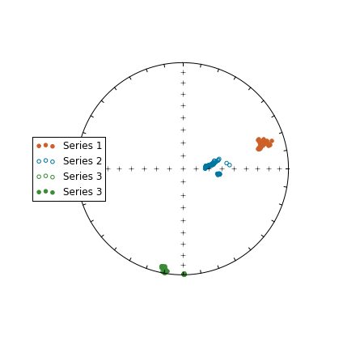

```python
directions_cart_series1_cooling=[]
directions_cart_series1_warming=[]

for n in range(len(Ikon_series1_cooling)):
    directions_cart_series1_cooling.append([Ikon_series1_cooling['Mx_bsub[Am2]'][n],
                                    Ikon_series1_cooling['My_bsub[Am2]'][n],
                                    Ikon_series1_cooling['Mz_bsub[Am2]'][n]])
for n in range(len(Ikon_series1_warming)):
    directions_cart_series1_warming.append([Ikon_series1_warming['Mx_bsub[Am2]'][n],
                                    Ikon_series1_warming['My_bsub[Am2]'][n],
                                    Ikon_series1_warming['Mz_bsub[Am2]'][n]])

directions_DI_series1_cooling=pmag.cart2dir(directions_cart_series1_cooling)
directions_DI_series1_warming=pmag.cart2dir(directions_cart_series1_warming)

directions_cart_series2_cooling=[]
directions_cart_series2_warming=[]

for n in range(len(Ikon_series2_cooling)):
    directions_cart_series2_cooling.append([Ikon_series2_cooling['Mx_bsub[Am2]'][n],
                                    Ikon_series2_cooling['My_bsub[Am2]'][n],
                                    Ikon_series2_cooling['Mz_bsub[Am2]'][n]])
for n in range(len(Ikon_series2_warming)):
    directions_cart_series2_warming.append([Ikon_series2_warming['Mx_bsub[Am2]'][n],
                                    Ikon_series2_warming['My_bsub[Am2]'][n],
                                    Ikon_series2_warming['Mz_bsub[Am2]'][n]])

directions_DI_series2_cooling=pmag.cart2dir(directions_cart_series2_cooling)
directions_DI_series2_warming=pmag.cart2dir(directions_cart_series2_warming)

directions_cart_series3_cooling=[]
directions_cart_series3_warming=[]

for n in range(len(Ikon_series3_cooling)):
    directions_cart_series3_cooling.append([Ikon_series3_cooling['Mx_bsub[Am2]'][n],
                                    Ikon_series3_cooling['My_bsub[Am2]'][n],
                                    Ikon_series3_cooling['Mz_bsub[Am2]'][n]])
for n in range(len(Ikon_series3_warming)):
    directions_cart_series3_warming.append([Ikon_series3_warming['Mx_bsub[Am2]'][n],
                                    Ikon_series3_warming['My_bsub[Am2]'][n],
                                    Ikon_series3_warming['Mz_bsub[Am2]'][n]])

directions_DI_series3_cooling=pmag.cart2dir(directions_cart_series3_cooling)
directions_DI_series3_warming=pmag.cart2dir(directions_cart_series3_warming)

fignum = 1
plt.figure(num=fignum,figsize=(6,6),dpi=160)
pmagplotlib.plotNET(fignum)
IPmag.iplotDI(directions_DI_series1_cooling,color='#CD5F28', label='Series 1')
IPmag.iplotDI(directions_DI_series1_warming,color='#CD5F28')
IPmag.iplotDI(directions_DI_series2_cooling,color='#0077A2', label='Series 2')
IPmag.iplotDI(directions_DI_series2_warming,color='#0077A2')
IPmag.iplotDI(directions_DI_series3_cooling,color='#3B8B36', label='Series 3')
IPmag.iplotDI(directions_DI_series3_warming,color='#3B8B36')
plt.legend(loc=6)
plt.savefig('code_output/Ikon_magnetite_EA.pdf')
plt.show()
```

### Additional plots of directional change in <100> experiment

There are some quite interesting directional changes in the Series 2 data set. The data from that experiment is plotted below on Zijderveld plots.

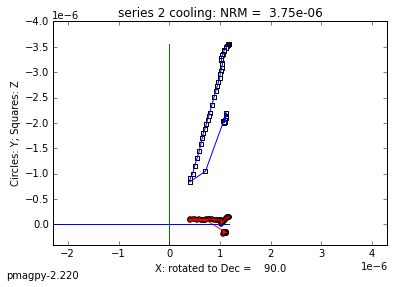

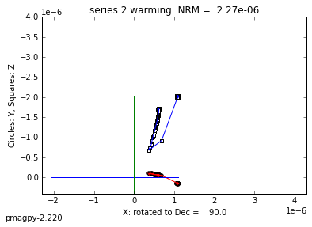

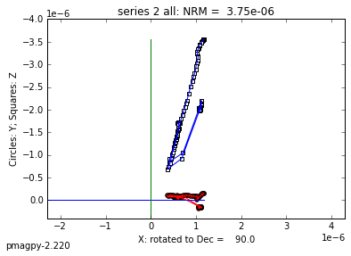

```python
#make a datablock with this format: [treatment step, dec, inc, intensity]
datablock_cooling=[]
for n in range(0,len(Ikon_series2_cooling)):
    datablock_cooling.append([Ikon_series2_cooling['Meas_T[K]'][n],
                      directions_DI_series2_cooling[n][0],
                      directions_DI_series2_cooling[n][1],
                      directions_DI_series2_cooling[n][2]])
datablock_warming=[]
for n in range(0,len(Ikon_series2_warming)):
    datablock_warming.append([Ikon_series2_warming['Meas_T[K]'][n],
                      directions_DI_series2_warming[n][0],
                      directions_DI_series2_warming[n][1],
                      directions_DI_series2_warming[n][2]])
datablock_all=datablock_cooling+datablock_warming

#plot with pmagplotlib.plotZ(fignum,datablock,angle,s,norm)
fignum = 1
pmagplotlib.plotZ(1,datablock_cooling,90,'series 2 cooling',0)
plt.ticklabel_format(style='sci', scilimits=(0,0), axis='y')
plt.ticklabel_format(style='sci', scilimits=(0,0), axis='x')
plt.ylim(.0000004,-.000004,)
plt.xlim(0,.000002,)
plt.savefig('code_output/Ikon_magnetite_series2_zplot_cooling.pdf')
plt.show()

fignum = 2
pmagplotlib.plotZ(1,datablock_warming,90,'series 2 warming',0)
plt.ticklabel_format(style='sci', scilimits=(0,0), axis='y')
plt.ticklabel_format(style='sci', scilimits=(0,0), axis='x')
plt.ylim(.0000004,-.000004,)
plt.xlim(0,.000002,)
plt.savefig('code_output/Ikon_magnetite_series2_zplot_warming.pdf')
plt.show()

fignum = 3
pmagplotlib.plotZ(1,datablock_all,90,'series 2 all',0)
plt.ticklabel_format(style='sci', scilimits=(0,0), axis='y')
plt.ticklabel_format(style='sci', scilimits=(0,0), axis='x')
plt.ylim(.0000004,-.000004,)
plt.xlim(0,.000002,)
plt.savefig('code_output/Ikon_magnetite_series2_zplot.pdf')
plt.show()
```

# Polycrystalline magnetite and hematite experiments

This sample is from a product marketed as "Nature Company hematite" (referred to as naco in the code and the data folder) that is a polycrystalline mix of hematite with magnetite impurity. Low-temperature cycling experiments on this specimen (cf-naco-1) were conducted on the IRM-LTI and the MPMS.

## IRM-LTI experiment

```python
Naco_cooling = pd.read_csv('../Data/NaCo/Naco_cooling.csv')
Naco_warming = pd.read_csv('../Data/NaCo/Naco_warming.csv')
Naco_cooling.head()
```

|  | specimen | Mx[Am2] | My[Am2] | Mz[Am2] | MN[Am2] | ME[Am2] | MV[Am2] | Mtot[Am2] | Dec[deg] | Inc[deg] | ... | time | series | position[cm] | Drift_ratio | Ja/Jr | run# | Description | Meas_T[K] | Mode | Type |
| --- | --- | --- | --- | --- | --- | --- | --- | --- | --- | --- | --- | --- | --- | --- | --- | --- | --- | --- | --- | --- | --- |
| 0 | cf-naco-1 | 0.000083 | -4.335590e-08 | -0.000003 | 0.000083 | -4.335590e-08 | -0.000003 | 0.000083 | -0.029839 | -2.17446 | ... | 10:41:36 AM | 1 | NaN | NaN | 0 | NaN | 292.893 | 291.28 | DISCRETE | NaN |
| 1 | cf-naco-1 | 0.000083 | -4.275720e-08 | -0.000003 | 0.000083 | -4.275720e-08 | -0.000003 | 0.000083 | -0.029466 | -2.18214 | ... | 10:45:05 AM | 1 | NaN | NaN | 0 | NaN | 292.920 | 291.26 | DISCRETE | NaN |
| 2 | cf-naco-1 | 0.000083 | -4.030780e-08 | -0.000003 | 0.000083 | -4.030780e-08 | -0.000003 | 0.000083 | -0.027778 | -2.17731 | ... | 10:46:28 AM | 1 | NaN | NaN | 0 | NaN | 292.929 | 291.26 | DISCRETE | NaN |
| 3 | cf-naco-1 | 0.000083 | -5.599900e-08 | -0.000003 | 0.000083 | -5.599900e-08 | -0.000003 | 0.000083 | -0.038592 | -2.18009 | ... | 10:48:48 AM | 1 | NaN | NaN | 0 | NaN | 284.969 | 291.23 | DISCRETE | NaN |
| 4 | cf-naco-1 | 0.000083 | -5.100280e-08 | -0.000003 | 0.000083 | -5.100280e-08 | -0.000003 | 0.000083 | -0.035174 | -2.17820 | ... | 11:32:19 AM | 1 | NaN | NaN | 0 | NaN | 181.799 | 290.19 | DISCRETE | NaN |

5 rows × 35 columns

### Blank run and background subtraction

A blank run with the probe empty was done close in time to the experiment on the cf-naco-a specimen. That data is imported below into a dataframe and then plotted to determine the best way to background subtract the probe measurement from the sample data.

```python
blank_naco_data_cooling = pd.read_csv('../Data/NaCo/20110520cf_blank_cooling.csv')
blank_naco_data_warming = pd.read_csv('../Data/NaCo/20110520cf_blank_warming.csv')
blank_naco_data_warming.head()
```

|  | specimen | Mx[Am2] | My[Am2] | Mz[Am2] | MN[Am2] | ME[Am2] | MV[Am2] | Mtot[Am2] | Dec[deg] | Inc[deg] | ... | time | series | position[cm] | Drift_ratio | Ja/Jr | run# | Description | Meas_T[K] | Mode | Type |
| --- | --- | --- | --- | --- | --- | --- | --- | --- | --- | --- | --- | --- | --- | --- | --- | --- | --- | --- | --- | --- | --- |
| 0 | CF-blank | -4.684120e-08 | -6.720820e-08 | 0 | 0 | -6.720820e-08 | 4.684120e-08 | 0 | -28.5181 | 18.4050 | ... | 1:17:33 PM | 7 | NaN | NaN | 0 | NaN | 15.227 | 17.63 | DISCRETE | NaN |
| 1 | CF-blank | -4.699740e-08 | -6.693490e-08 | 0 | 0 | -6.693490e-08 | 4.699740e-08 | 0 | -28.4446 | 18.4917 | ... | 1:18:19 PM | 7 | NaN | NaN | 0 | NaN | 18.948 | 22.16 | DISCRETE | NaN |
| 2 | CF-blank | -4.690780e-08 | -6.685280e-08 | 0 | 0 | -6.685280e-08 | 4.690780e-08 | 0 | -28.4037 | 18.4572 | ... | 1:19:10 PM | 7 | NaN | NaN | 0 | NaN | 20.988 | 24.07 | DISCRETE | NaN |
| 3 | CF-blank | -4.700080e-08 | -6.680970e-08 | 0 | 0 | -6.680970e-08 | 4.700080e-08 | 0 | -28.4008 | 18.5009 | ... | 1:20:15 PM | 7 | NaN | NaN | 0 | NaN | 22.501 | 25.58 | DISCRETE | NaN |
| 4 | CF-blank | -4.673360e-08 | -6.666500e-08 | 0 | 0 | -6.666500e-08 | 4.673360e-08 | 0 | -28.3368 | 18.4045 | ... | 1:21:35 PM | 7 | NaN | NaN | 0 | NaN | 23.577 | 27.08 | DISCRETE | NaN |

5 rows × 35 columns

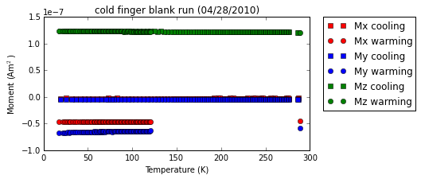

```python
blank_naco_data_cooling = pd.read_csv('../Data/NaCo/20110520cf_blank_cooling.csv')
blank_naco_data_warming = pd.read_csv('../Data/NaCo/20110520cf_blank_warming.csv')
blank_naco_data_warming.head()
fignum=1
plt.figure(num=fignum,figsize=(6,3),dpi=160)
plt.plot(blank_naco_data_cooling['Meas_T[K]'], blank_naco_data_cooling['Mx[Am2]'], 'rs',
         label='Mx cooling')
plt.plot(blank_naco_data_warming['Meas_T[K]'], blank_naco_data_warming['Mx[Am2]'], 'ro',
         label='Mx warming')
plt.plot(blank_naco_data_cooling['Meas_T[K]'], blank_naco_data_cooling['My[Am2]'], 'bs',
         label='My cooling')
plt.plot(blank_naco_data_warming['Meas_T[K]'], blank_naco_data_warming['My[Am2]'], 'bo',
         label='My warming')
plt.plot(blank_naco_data_cooling['Meas_T[K]'], blank_naco_data_cooling['Mz[Am2]'], 'gs',
         label='Mz cooling')
plt.plot(blank_naco_data_warming['Meas_T[K]'], blank_naco_data_warming['Mz[Am2]'], 'go',
         label='Mz warming')

plt.ylabel('Moment (Am$^2$)')
plt.xlabel('Temperature (K)')
plt.legend(bbox_to_anchor=(1.05, 1), loc=2, borderaxespad=0.)
plt.title('cold finger blank run (04/28/2010)')

plt.show()
```

The cooling run was completed in full for the blank while there were gaps in the warming data. Let's use the cooling data which looks to be reversible for the z (while there is an unexplained offset in the y and x) for the background correction using the background_subtraction() function.

```python
#For the interpolate function to work the x values (temperature) need to be ascending.
#The blank_hem_data_cooling can be sorted so that temperatures are ascending
blank_naco_data_cooling = blank_naco_data_cooling.sort(['Meas_T[K]'])

Naco_cooling['Mx_bsub[Am2]'] = background_sub(blank_naco_data_cooling['Mx[Am2]'],
                                              blank_naco_data_cooling['Meas_T[K]'],
                                              Naco_cooling['Mx[Am2]'],
                                              Naco_cooling['Meas_T[K]'])

Naco_cooling['My_bsub[Am2]'] = background_sub(blank_naco_data_cooling['My[Am2]'],
                                              blank_naco_data_cooling['Meas_T[K]'],
                                              Naco_cooling['My[Am2]'],
                                              Naco_cooling['Meas_T[K]'])

Naco_cooling['Mz_bsub[Am2]'] = background_sub(blank_naco_data_cooling['Mz[Am2]'],
                                              blank_naco_data_cooling['Meas_T[K]'],
                                              Naco_cooling['Mz[Am2]'],
                                              Naco_cooling['Meas_T[K]'])

Naco_cooling['Mtotal_bsub[Am2]'] = np.sqrt(Naco_cooling['Mx_bsub[Am2]']**2 +
                                           Naco_cooling['My_bsub[Am2]']**2 +
                                           Naco_cooling['Mz_bsub[Am2]']**2)

Naco_warming['Mx_bsub[Am2]'] = background_sub(blank_naco_data_cooling['Mx[Am2]'],
                                              blank_naco_data_cooling['Meas_T[K]'],
                                              Naco_warming['Mx[Am2]'],
                                              Naco_warming['Meas_T[K]'])

Naco_warming['My_bsub[Am2]'] = background_sub(blank_naco_data_cooling['My[Am2]'],
                                              blank_naco_data_cooling['Meas_T[K]'],
                                              Naco_warming['My[Am2]'],
                                              Naco_warming['Meas_T[K]'])

Naco_warming['Mz_bsub[Am2]'] = background_sub(blank_naco_data_cooling['Mz[Am2]'],
                                              blank_naco_data_cooling['Meas_T[K]'],
                                              Naco_warming['Mz[Am2]'],
                                              Naco_warming['Meas_T[K]'])

Naco_warming['Mtotal_bsub[Am2]'] = np.sqrt(Naco_warming['Mx_bsub[Am2]']**2 +
                                           Naco_warming['My_bsub[Am2]']**2 +
                                           Naco_warming['Mz_bsub[Am2]']**2)
```

## Equal area plot

The direction of the Naco specimen throughout thermal cycling on the LTI can be plotted on an equal area plot. A subsection of this equal area plot was included in the figure concerning the Naco hematite/magnetite specimen in the main text.

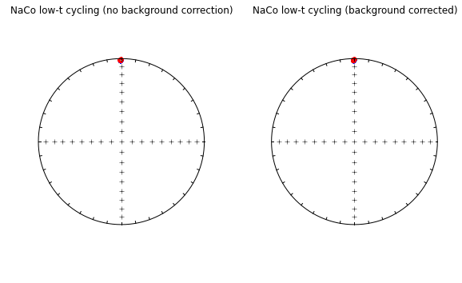

```python
directions_cart_cooling=[]
directions_cart_warming=[]

#data point 0 is oriented (remember python starts at 0)
for n in range(len(Naco_cooling)):
    directions_cart_cooling.append([Naco_cooling['Mx[Am2]'][n],
                                    Naco_cooling['My[Am2]'][n],
                                    Naco_cooling['Mz[Am2]'][n]])
for n in range(len(Naco_warming)):
    directions_cart_warming.append([Naco_warming['Mx[Am2]'][n],
                                    Naco_warming['My[Am2]'][n],
                                    Naco_warming['Mz[Am2]'][n]])

directions_DI_cooling=pmag.cart2dir(directions_cart_cooling)
directions_DI_warming=pmag.cart2dir(directions_cart_warming)

directions_cart_cooling=[]
directions_cart_warming=[]

#data point 0 is oriented (remember python starts at 0)
for n in range(len(Naco_cooling)):
    directions_cart_cooling.append([Naco_cooling['Mx_bsub[Am2]'][n],
                                    Naco_cooling['My_bsub[Am2]'][n],
                                    Naco_cooling['Mz_bsub[Am2]'][n]])
for n in range(len(Naco_warming)):
    directions_cart_warming.append([Naco_warming['Mx_bsub[Am2]'][n],
                                    Naco_warming['My_bsub[Am2]'][n],
                                    Naco_warming['Mz_bsub[Am2]'][n]])

directions_DI_cooling=pmag.cart2dir(directions_cart_cooling)
directions_DI_warming=pmag.cart2dir(directions_cart_warming)

fignum=1
fig=plt.figure(figsize=(8,5),dpi=160)
plt.subplot(121)
plt.figure(num=fignum,figsize=(8,8),dpi=160)
pmagplotlib.plotNET(fignum)
IPmag.iplotDI(directions_DI_cooling,'b')
IPmag.iplotDI(directions_DI_warming,'r')
plt.title('NaCo low-t cycling (no background correction)')

plt.subplot(122)
plt.figure(num=fignum,figsize=(8,8),dpi=160)
pmagplotlib.plotNET(fignum)
IPmag.iplotDI(directions_DI_cooling,'b')
IPmag.iplotDI(directions_DI_warming,'r')
plt.title('NaCo low-t cycling (background corrected)')
plt.savefig('code_output/Naco_directions.pdf')
plt.show()
```

## Comparision between IRM-LTI and MPMS data

Having subtracted the holder off of the LTI experiment data, the background subtracted data is plotted below along with the data acquired during the low-temperature cycling experiment on the MPMS.

```python
Naco_MPMS = pd.read_csv('../Data/NaCo/Naco_MPMS.csv',header=3)
Naco_MPMS.head()
```

|  | T [K] | Bapp [T] | M [Am2/kg] | reg fit | timestamp | Unnamed: 5 | T [K].1 | Bapp [T].1 | M [Am2/kg].1 | reg fit.1 | timestamp.1 |
| --- | --- | --- | --- | --- | --- | --- | --- | --- | --- | --- | --- |
| 0 | NaN | NaN | NaN | NaN | NaN | NaN | NaN | NaN | NaN | NaN | NaN |
| 1 | 300.0231 | 0 | 0.744367 | 0.974488 | 5/27/2011 2:06:42 PM | NaN | 14.99718 | 0 | 0.079222 | 0.974658 | 5/27/2011 3:28:22 PM |
| 2 | 294.4838 | 0 | 0.744338 | 0.974525 | 5/27/2011 2:10:08 PM | NaN | 20.55822 | 0 | 0.079240 | 0.974714 | 5/27/2011 3:29:41 PM |
| 3 | 289.3426 | 0 | 0.742235 | 0.974490 | 5/27/2011 2:11:13 PM | NaN | 25.55299 | 0 | 0.079243 | 0.974558 | 5/27/2011 3:30:42 PM |
| 4 | 284.1801 | 0 | 0.739180 | 0.974057 | 5/27/2011 2:12:05 PM | NaN | 30.67751 | 0 | 0.079225 | 0.974482 | 5/27/2011 3:31:44 PM |

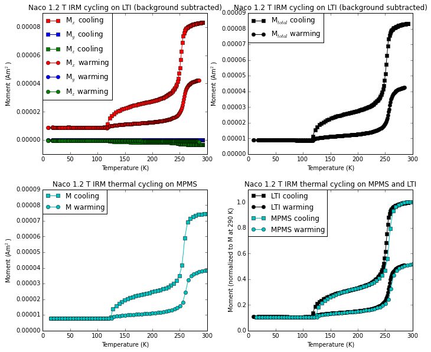

```python
adjustprops = dict(left=0.1, bottom=0.1, right=0.97, top=0.93, wspace=0.25, hspace=0.25)
fig=plt.figure(figsize=(10,9))
fig.subplots_adjust(**adjustprops)
ax1 = plt.subplot(221)

ax1.plot(Naco_cooling['Meas_T[K]'], Naco_cooling['Mx_bsub[Am2]'], 'rs-',label='M$_x$ cooling')
ax1.plot(Naco_cooling['Meas_T[K]'], Naco_cooling['My_bsub[Am2]'], 'bs-',label='M$_y$ cooling')
ax1.plot(Naco_cooling['Meas_T[K]'], Naco_cooling['Mz_bsub[Am2]'], 'gs-',label='M$_z$ cooling')
ax1.plot(Naco_warming['Meas_T[K]'], Naco_warming['Mx_bsub[Am2]'], 'ro-',label='M$_x$ warming')
ax1.plot(Naco_warming['Meas_T[K]'], Naco_warming['My_bsub[Am2]'], 'bo-',label='M$_y$ warming')
ax1.plot(Naco_warming['Meas_T[K]'], Naco_warming['Mz_bsub[Am2]'], 'go-',label='M$_z$ warming')
plt.legend(loc=2, borderaxespad=0.)
plt.ylabel('Moment (Am$^2$)')
plt.xlabel('Temperature (K)')
plt.title('Naco 1.2 T IRM cycling on LTI (background subtracted)')

ax2 = plt.subplot(222)
ax2.plot(Naco_cooling['Meas_T[K]'], Naco_cooling['Mtotal_bsub[Am2]'],
         'ks-',label='M$_{total}$ cooling')
ax2.plot(Naco_warming['Meas_T[K]'], Naco_warming['Mtotal_bsub[Am2]'],
         'ko-',label='M$_{total}$ warming')
plt.legend(loc=2, borderaxespad=0.)
plt.ylabel('Moment (Am$^2$)')
plt.xlabel('Temperature (K)')
plt.title('Naco 1.2 T IRM cycling on LTI (background subtracted)')

ax3 = plt.subplot(223)
ax3.plot(Naco_MPMS['T [K]'],Naco_MPMS['M [Am2/kg]']/10000,'cs-',label='M cooling')
ax3.plot(Naco_MPMS['T [K].1'],Naco_MPMS['M [Am2/kg].1']/10000,'co-',label='M warming')
plt.legend(loc=2, borderaxespad=0.)
plt.ylabel('Moment (Am$^2$)')
plt.ylim(0,0.00009)
plt.xlabel('Temperature (K)')
plt.xlim(0,300)
plt.title('Naco 1.2 T IRM thermal cycling on MPMS')

ax4 = plt.subplot(224)
ax4.plot(Naco_cooling['Meas_T[K]'],
         Naco_cooling['Mtotal_bsub[Am2]']/Naco_cooling['Mtotal_bsub[Am2]'][0],
         'ks-',label='LTI cooling')
ax4.plot(Naco_warming['Meas_T[K]'],
         Naco_warming['Mtotal_bsub[Am2]']/Naco_cooling['Mtotal_bsub[Am2]'][0],
         'ko-',label='LTI warming')
ax4.plot(Naco_MPMS['T [K]'],
         Naco_MPMS['M [Am2/kg]']/Naco_MPMS['M [Am2/kg]'][3],
         'cs-',label='MPMS cooling')
ax4.plot(Naco_MPMS['T [K].1'],
         Naco_MPMS['M [Am2/kg].1']/Naco_MPMS['M [Am2/kg]'][3],
         'co-',label='MPMS warming')
plt.ylabel('Moment (normalized to M at 290 K)')
plt.xlabel('Temperature (K)')
plt.legend(loc=2, borderaxespad=0.)
plt.xlim(0,300)
plt.ylim(ymin=0)
plt.title('Naco 1.2 T IRM thermal cycling on MPMS and LTI')
plt.show()
```

The total magnetic moment between the LTI and MPMS are quite similiar. The values obtained on the LTI are slightly higher which could be associated with there being small off-axis components that were not resolved using the MPMS. The code block below displays the values of the magnetic moments at ~290 degrees on both instruments. These values are written on the figure in the main manuscript.

```python
#values quoted on figure
a = Naco_cooling['Mtotal_bsub[Am2]'][0]
b = Naco_cooling['Meas_T[K]'][5]
print "For the temperature of", b, "on the LTI the magnetic moment is:", a, "Am2"
c = Naco_MPMS['T [K]'][3]
d = Naco_MPMS['M [Am2/kg]'][3]/10000
print "For the temperature of", c, "on the MPMS the magnetic moment is:", d, "Am2"
print "Number of data points collected during LTI run:", len(Naco_cooling['Meas_T[K]'])
```

```
For the temperature of 289.13 on the LTI the magnetic moment is: 8.33181600855e-05 Am2
For the temperature of 289.3426 on the MPMS the magnetic moment is: 7.422345e-05 Am2
Number of data points collected during LTI run: 114
```

A simplified version of the figure made above needs to be generated to use within the main manuscript.

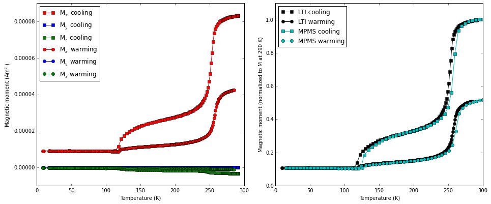

```python
adjustprops = dict(left=0.1, bottom=0.1, right=0.97, top=0.93, wspace=0.15, hspace=0.1)
fig=plt.figure(figsize=(14,6),dpi=160)
fig.subplots_adjust(**adjustprops)

ax1 = plt.subplot(121)
ax1.plot(Naco_cooling['Meas_T[K]'], Naco_cooling['Mx_bsub[Am2]'],
         'rs-',label='M$_x$ cooling')
ax1.plot(Naco_cooling['Meas_T[K]'], Naco_cooling['My_bsub[Am2]'],
         'bs-',label='M$_y$ cooling')
ax1.plot(Naco_cooling['Meas_T[K]'], Naco_cooling['Mz_bsub[Am2]'],
         'gs-',label='M$_z$ cooling')
ax1.plot(Naco_warming['Meas_T[K]'], Naco_warming['Mx_bsub[Am2]'],
         'ro-',label='M$_x$ warming')
ax1.plot(Naco_warming['Meas_T[K]'], Naco_warming['My_bsub[Am2]'],
         'bo-',label='M$_y$ warming')
ax1.plot(Naco_warming['Meas_T[K]'], Naco_warming['Mz_bsub[Am2]'],
         'go-',label='M$_z$ warming')
plt.legend(loc=2)
plt.ylabel('Magnetic moment (Am$^2$)')
plt.xlabel('Temperature (K)')
#plt.title('thermal cycling on IRM-LTI (background subtracted)')

ax2 = plt.subplot(122)
ax2.plot(Naco_cooling['Meas_T[K]'],
         Naco_cooling['Mtotal_bsub[Am2]']/Naco_cooling['Mtotal_bsub[Am2]'][0],
         'ks-',label='LTI cooling')
ax2.plot(Naco_warming['Meas_T[K]'],
         Naco_warming['Mtotal_bsub[Am2]']/Naco_cooling['Mtotal_bsub[Am2]'][0],
         'ko-',label='LTI warming')
ax2.plot(Naco_MPMS['T [K]'],Naco_MPMS['M [Am2/kg]']/Naco_MPMS['M [Am2/kg]'][3],
         'cs-',label='MPMS cooling')
ax2.plot(Naco_MPMS['T [K].1'],Naco_MPMS['M [Am2/kg].1']/Naco_MPMS['M [Am2/kg]'][3],
         'co-',label='MPMS warming')
plt.ylabel('Magnetic moment (normalized to M at 290 K)')
plt.xlabel('Temperature (K)')
#plt.title('thermal cycling on IRM-LTI and MPMS')
plt.legend(loc=2)
plt.xlim(0,300)
plt.ylim(ymin=0)
plt.savefig('code_output/Naco_LTcycle.pdf')
plt.show()
```

### Estimating Morin and Verwey transition temperatures

In order to estimate the Morin and Verwey transition temperatures, the gradient of the cooling data can be plotted.

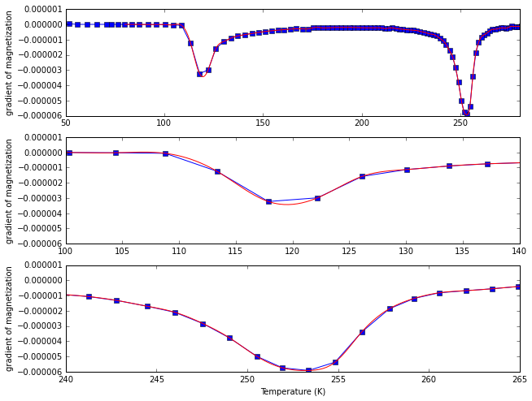

```python
gradient_LTI_cooling = np.gradient(Naco_cooling['Mtotal_bsub[Am2]'])

from scipy.interpolate import interp1d

#interpolate the data using a cubic spline
f_LTI_cooling_inter =  interp1d(Naco_cooling['Meas_T[K]'][3:],
                                gradient_LTI_cooling[3:],
                                kind='cubic')

xnew = np.linspace(80,280,1000)

gradient_LTI_cooling_interpolated = f_LTI_cooling_inter(xnew)

plt.figure(figsize=(10,8),dpi=160)
plt.subplot(311)
plt.plot(Naco_cooling['Meas_T[K]'], gradient_LTI_cooling,
         'bs-',label='LTI gradient on cooling')
plt.plot(xnew, gradient_LTI_cooling_interpolated, 'r-')
plt.xlim(50, 280)
plt.ylabel('gradient of magnetization')

plt.subplot(312)
plt.plot(Naco_cooling['Meas_T[K]'], gradient_LTI_cooling,
         'bs-',label='LTI gradient on cooling')
plt.plot(xnew, gradient_LTI_cooling_interpolated, 'r-')
plt.xlim(100, 140)
plt.ylabel('gradient of magnetization')

plt.subplot(313)
plt.plot(Naco_cooling['Meas_T[K]'], gradient_LTI_cooling,
         'bs-',label='LTI gradient on cooling')
plt.plot(xnew, gradient_LTI_cooling_interpolated, 'r-')
plt.xlim(240, 265)
plt.ylabel('gradient of magnetization')

plt.xlabel('Temperature (K)')
plt.show()
```

```python
LTI_morin = fmin(f_LTI_cooling_inter, x0=252)
print 'The Morin estimate using LTI cooling data is: ' + str(LTI_morin)
print ""
LTI_verwey = fmin(f_LTI_cooling_inter, x0=118)
print 'The Verwey estimate using LTI cooling data is: ' + str(LTI_verwey)
print ""
```

```
Optimization terminated successfully.
         Current function value: -0.000006
         Iterations: 18
         Function evaluations: 36
The Morin estimate using LTI cooling data is: [ 253.17009888]

Optimization terminated successfully.
         Current function value: -0.000003
         Iterations: 17
         Function evaluations: 34
The Verwey estimate using LTI cooling data is: [ 119.51677246]
```

# Pyrrhotite experiments

## IRM-LTI experiments

There were three experiments performed on this single crystal of pyrrhotite:

- an isothermal remanent magnetization bisecting the c and a$_1$ axes (series 5)
- an isothermal remanent magnetization along the c axis (series 6)
- an isothermal remanent magnetization bisecting the a$_1$ and -a$_3$ axes (series 7)

Import the data into a dataframe

```python
pyrrhotite_data = pd.read_csv('../Data/Pyrrhotite/Pyrrhotite_Experiments.csv')
```

### Blank run and background subtraction

A blank run of the empty coldfinger probe was conducted on 2/6/2012 (the day before the series 5 experiment). The data can be loaded into a dataframe.

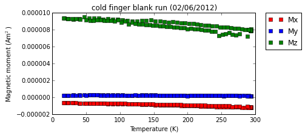

```python
blank_for_pyrrhotite = pd.read_csv('../Data/Pyrrhotite/cf_blank.csv')

plt.figure(figsize=(6,3),dpi=160)
plt.plot(blank_for_pyrrhotite['measurement_T[K]'], blank_for_pyrrhotite['Mx[Am2]'],
         'rs', label='Mx')
plt.plot(blank_for_pyrrhotite['measurement_T[K]'], blank_for_pyrrhotite['My[Am2]'],
         'bs', label='My')
plt.plot(blank_for_pyrrhotite['measurement_T[K]'], blank_for_pyrrhotite['Mz[Am2]'],
         'gs', label='Mz')
plt.ylabel('Magnetic moment (Am$^2$)')
plt.xlabel('Temperature (K)')
plt.legend(bbox_to_anchor=(1.05, 1), loc=2, borderaxespad=0.)
plt.title('cold finger blank run (02/06/2012)')
plt.show()
```

The probe's magnetic moment appears to be largely reversible. Let's use the values upon cooling of the blank probe for the background correction of the pyrrhotite experimental data.

```python
blank_for_pyrrhotite_cooling = blank_for_pyrrhotite[0:51]
blank_for_pyrrhotite_cooling = blank_for_pyrrhotite_cooling.sort(['measurement_T[K]'])

pyrrhotite_data['Mx_bsub[Am2]'] = background_sub(blank_for_pyrrhotite_cooling['Mx[Am2]'],
                                                 blank_for_pyrrhotite_cooling['measurement_T[K]'],
                                                 pyrrhotite_data['Mx[Am2]'],
                                                 pyrrhotite_data['Meas_T[K]'])
pyrrhotite_data['My_bsub[Am2]'] = background_sub(blank_for_pyrrhotite_cooling['My[Am2]'],
                                                 blank_for_pyrrhotite_cooling['measurement_T[K]'],
                                                 pyrrhotite_data['My[Am2]'],
                                                 pyrrhotite_data['Meas_T[K]'])
pyrrhotite_data['Mz_bsub[Am2]'] = background_sub(blank_for_pyrrhotite_cooling['Mz[Am2]'],
                                                 blank_for_pyrrhotite_cooling['measurement_T[K]'],
                                                 pyrrhotite_data['Mz[Am2]'],
                                                 pyrrhotite_data['Meas_T[K]'])

pyrrhotite_data['Mtotal_bsub[Am2]'] = np.sqrt(pyrrhotite_data['Mx_bsub[Am2]']**2 +
                                           pyrrhotite_data['My_bsub[Am2]']**2 +
                                           pyrrhotite_data['Mz_bsub[Am2]']**2)
```

### 3-axis and total magnetization plots

Split the data into series 5, 6 and 7, reset the indices for each series and view the first 5 rows of pyrrhotite_data_series7.

```python
pyrrhotite_data_series5 = pyrrhotite_data.ix[pyrrhotite_data.series==5]
pyrrhotite_data_series6 = pyrrhotite_data.ix[pyrrhotite_data.series==6]
pyrrhotite_data_series6.reset_index(inplace=True)
pyrrhotite_data_series7 = pyrrhotite_data.ix[pyrrhotite_data.series==7]
pyrrhotite_data_series7.reset_index(inplace=True)
pyrrhotite_data_series7.head()
```

|  | index | specimen | Mx[Am2] | My[Am2] | Mz[Am2] | MN[Am2] | ME[Am2] | MV[Am2] | Mtot[Am2] | Dec[deg] | ... | Ja/Jr | run# | Description | Meas_T[K] | Mode | Type | Mx_bsub[Am2] | My_bsub[Am2] | Mz_bsub[Am2] | Mtotal_bsub[Am2] |
| --- | --- | --- | --- | --- | --- | --- | --- | --- | --- | --- | --- | --- | --- | --- | --- | --- | --- | --- | --- | --- | --- |
| 0 | 230 | CF AA pyrrhotite-5 | 0.000130 | 0.000063 | -0.000029 | 0.000130 | 0.000063 | -0.000029 | 0.000147 | 25.83010 | ... | 0 | NaN | 289.42 | 290.745 | DISCRETE | NaN | 0.000131 | 0.000063 | -0.000037 | 0.000150 |
| 1 | 231 | CF AA pyrrhotite-5 | 0.000148 | 0.000007 | -0.000051 | 0.000148 | 0.000007 | -0.000051 | 0.000156 | 2.89964 | ... | 0 | NaN | 290.98 | 291.961 | DISCRETE | NaN | 0.000149 | 0.000007 | -0.000062 | 0.000162 |
| 2 | 232 | CF AA pyrrhotite-5 | 0.000148 | 0.000007 | -0.000051 | 0.000148 | 0.000007 | -0.000051 | 0.000156 | 2.88449 | ... | 0 | NaN | 291.24 | 292.114 | DISCRETE | NaN | 0.000149 | 0.000007 | -0.000062 | 0.000161 |
| 3 | 233 | CF AA pyrrhotite-5 | 0.000148 | 0.000007 | -0.000051 | 0.000148 | 0.000007 | -0.000051 | 0.000156 | 2.87935 | ... | 0 | NaN | 291.33 | 292.170 | DISCRETE | NaN | 0.000149 | 0.000007 | -0.000062 | 0.000161 |
| 4 | 234 | CF AA pyrrhotite-5 | 0.000148 | 0.000007 | -0.000051 | 0.000148 | 0.000007 | -0.000051 | 0.000156 | 2.87825 | ... | 0 | NaN | 291.40 | 292.230 | DISCRETE | NaN | 0.000149 | 0.000007 | -0.000062 | 0.000161 |

5 rows × 40 columns

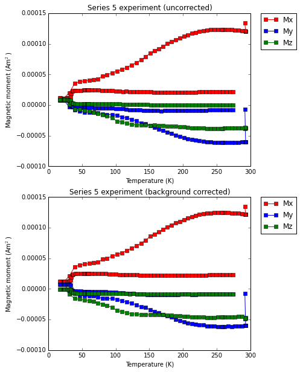

```python
plt.figure(figsize=(6,10),dpi=160)
plt.subplot(211)
plt.plot(pyrrhotite_data_series5['Meas_T[K]'], pyrrhotite_data_series5['Mx[Am2]'],
         'rs-', label='Mx')
plt.plot(pyrrhotite_data_series5['Meas_T[K]'], pyrrhotite_data_series5['My[Am2]'],
         'bs-', label='My')
plt.plot(pyrrhotite_data_series5['Meas_T[K]'], pyrrhotite_data_series5['Mz[Am2]'],
         'gs-', label='Mz')
plt.ylabel('Magnetic moment (Am$^2$)')
plt.xlabel('Temperature (K)')
plt.legend(bbox_to_anchor=(1.05, 1), loc=2, borderaxespad=0.)
plt.title('Series 5 experiment (uncorrected)')
plt.subplot(212)
plt.plot(pyrrhotite_data_series5['Meas_T[K]'], pyrrhotite_data_series5['Mx_bsub[Am2]'],
         'rs-', label='Mx')
plt.plot(pyrrhotite_data_series5['Meas_T[K]'], pyrrhotite_data_series5['My_bsub[Am2]'],
         'bs-', label='My')
plt.plot(pyrrhotite_data_series5['Meas_T[K]'], pyrrhotite_data_series5['Mz_bsub[Am2]'],
         'gs-', label='Mz')
plt.ylabel('Magnetic moment (Am$^2$)')
plt.xlabel('Temperature (K)')
plt.legend(bbox_to_anchor=(1.05, 1), loc=2, borderaxespad=0.)
plt.title('Series 5 experiment (background corrected)')
plt.show()
```

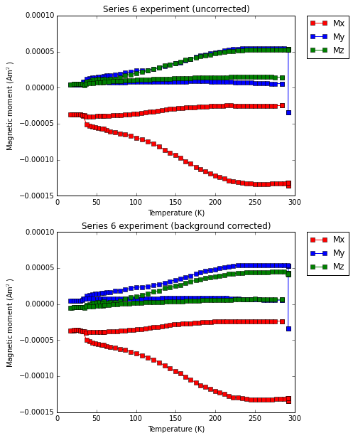

```python
plt.figure(figsize=(6,10),dpi=160)
plt.subplot(211)
plt.plot(pyrrhotite_data_series6['Meas_T[K]'], pyrrhotite_data_series6['Mx[Am2]'],
         'rs-', label='Mx')
plt.plot(pyrrhotite_data_series6['Meas_T[K]'], pyrrhotite_data_series6['My[Am2]'],
         'bs-', label='My')
plt.plot(pyrrhotite_data_series6['Meas_T[K]'], pyrrhotite_data_series6['Mz[Am2]'],
         'gs-', label='Mz')
plt.ylabel('Magnetic moment (Am$^2$)')
plt.xlabel('Temperature (K)')
plt.legend(bbox_to_anchor=(1.05, 1), loc=2, borderaxespad=0.)
plt.title('Series 6 experiment (uncorrected)')
plt.subplot(212)
plt.plot(pyrrhotite_data_series6['Meas_T[K]'], pyrrhotite_data_series6['Mx_bsub[Am2]'],
         'rs-', label='Mx')
plt.plot(pyrrhotite_data_series6['Meas_T[K]'], pyrrhotite_data_series6['My_bsub[Am2]'],
         'bs-', label='My')
plt.plot(pyrrhotite_data_series6['Meas_T[K]'], pyrrhotite_data_series6['Mz_bsub[Am2]'],
         'gs-',label='Mz')
plt.ylabel('Magnetic moment (Am$^2$)')
plt.xlabel('Temperature (K)')
plt.legend(bbox_to_anchor=(1.05, 1), loc=2, borderaxespad=0.)
plt.title('Series 6 experiment (background corrected)')
plt.show()
```

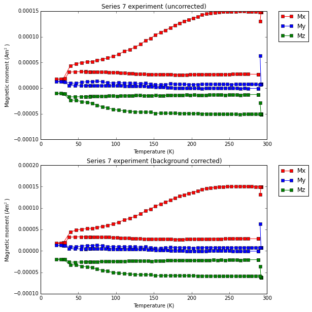

```python
plt.figure(figsize=(8,10),dpi=160)
plt.subplot(211)
plt.plot(pyrrhotite_data_series7['Meas_T[K]'], pyrrhotite_data_series7['Mx[Am2]'],
         'rs-', label='Mx')
plt.plot(pyrrhotite_data_series7['Meas_T[K]'], pyrrhotite_data_series7['My[Am2]'],
         'bs-', label='My')
plt.plot(pyrrhotite_data_series7['Meas_T[K]'], pyrrhotite_data_series7['Mz[Am2]'],
         'gs-', label='Mz')
plt.ylabel('Magnetic moment (Am$^2$)')
plt.xlabel('Temperature (K)')
plt.legend(bbox_to_anchor=(1.05, 1), loc=2, borderaxespad=0.)
plt.title('Series 7 experiment (uncorrected)')
plt.subplot(212)
plt.plot(pyrrhotite_data_series7['Meas_T[K]'], pyrrhotite_data_series7['Mx_bsub[Am2]'],
         'rs-', label='Mx')
plt.plot(pyrrhotite_data_series7['Meas_T[K]'], pyrrhotite_data_series7['My_bsub[Am2]'],
         'bs-', label='My')
plt.plot(pyrrhotite_data_series7['Meas_T[K]'], pyrrhotite_data_series7['Mz_bsub[Am2]'],
         'gs-', label='Mz')
plt.ylabel('Magnetic moment (Am$^2$)')
plt.xlabel('Temperature (K)')
plt.legend(bbox_to_anchor=(1.05, 1), loc=2, borderaxespad=0.)
plt.title('Series 7 experiment (background corrected)')
plt.show()
```

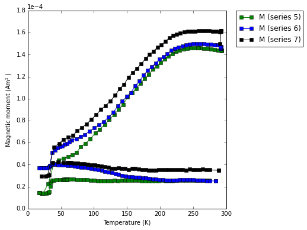

```python
plt.figure(figsize=(6,6),dpi=160)
plt.plot(pyrrhotite_data_series5['Meas_T[K]'],
         pyrrhotite_data_series5['Mtotal_bsub[Am2]'],
         'gs-', label='M (series 5)')
plt.plot(pyrrhotite_data_series6['Meas_T[K]'],
         pyrrhotite_data_series6['Mtotal_bsub[Am2]'],
         'bs-', label='M (series 6)')
plt.plot(pyrrhotite_data_series7['Meas_T[K]'],
         pyrrhotite_data_series7['Mtotal_bsub[Am2]'],
         'ks-', label='M (series 7)')
plt.legend(bbox_to_anchor=(1.05, 1), loc=2, borderaxespad=0.)
plt.ticklabel_format(style='sci', scilimits=(0,0), axis='y')
plt.ylabel('Magnetic moment (Am$^2$)')
plt.xlabel('Temperature (K)')
plt.savefig('code_output/pyrrhotite_totalM_allseries.pdf')
plt.show()
```

```python
pyrrhotite_data_series7['Meas_T[K]']
```

```
0     290.745
1     291.961
2     292.114
3     292.170
4     292.230
5     292.252
6     292.283
7     291.859
8     291.835
9     290.075
10    284.960
11    279.741
12    274.496
13    269.182
14    263.808
```

[output cut: 17 more lines]

```python
s5_temp_290 = pyrrhotite_data_series5['Meas_T[K]'][3]
s5_moment_290 = pyrrhotite_data_series5['Mtotal_bsub[Am2]'][3]

s5_temp_20 = pyrrhotite_data_series5['Meas_T[K]'][49]
s5_moment_20 = pyrrhotite_data_series5['Mtotal_bsub[Am2]'][49]

s5_temp_last = pyrrhotite_data_series5['Meas_T[K]'][114]
s5_moment_last = pyrrhotite_data_series5['Mtotal_bsub[Am2]'][114]

print 'For the series 5 experiment'
print "The percentage remanence remaining after cooling from " + str(s5_temp_290) + " to " + str(s5_temp_20) + " is "
print s5_moment_20/s5_moment_290*100

print "The percentage remanence remaining after thermal cycling back to " + str(s5_temp_last) + " is "
print s5_moment_last/s5_moment_290*100

s6_temp_290 = pyrrhotite_data_series6['Meas_T[K]'][6]
s6_moment_290 = pyrrhotite_data_series6['Mtotal_bsub[Am2]'][6]

s6_temp_20 = pyrrhotite_data_series6['Meas_T[K]'][56]
s6_moment_20 = pyrrhotite_data_series6['Mtotal_bsub[Am2]'][56]

s6_temp_last = pyrrhotite_data_series6['Meas_T[K]'][114]
s6_moment_last = pyrrhotite_data_series6['Mtotal_bsub[Am2]'][114]

print ""
print 'For the series 6 experiment'
print "The percentage remanence remaining after cooling from " + str(s6_temp_290) + " to " + str(s6_temp_20) + " is "
print s6_moment_20/s6_moment_290*100

print "The percentage remanence remaining after thermal cycling back to " + str(s5_temp_last) + " is "
print s6_moment_last/s6_moment_290*100

s7_temp_290 = pyrrhotite_data_series7['Meas_T[K]'][9]
s7_moment_290 = pyrrhotite_data_series7['Mtotal_bsub[Am2]'][9]

s7_temp_20 = pyrrhotite_data_series7['Meas_T[K]'][51]
s7_moment_20 = pyrrhotite_data_series7['Mtotal_bsub[Am2]'][51]

s7_temp_last = pyrrhotite_data_series7['Meas_T[K]'][103]
s7_moment_last = pyrrhotite_data_series7['Mtotal_bsub[Am2]'][103]

print ""
print 'For the series 6 experiment'
print "The percentage remanence remaining after cooling from " + str(s7_temp_290) + " to " + str(s7_temp_20) + " is "
print s7_moment_20/s7_moment_290*100

print "The percentage remanence remaining after thermal cycling back to " + str(s5_temp_last) + " is "
print s7_moment_last/s7_moment_290*100
```

```
For the series 5 experiment
The percentage remanence remaining after cooling from 292.01 to 20.604 is
9.75562057483
The percentage remanence remaining after thermal cycling back to 274.388 is
17.6555731402

For the series 6 experiment
The percentage remanence remaining after cooling from 291.577 to 18.551 is
25.1795062718
The percentage remanence remaining after thermal cycling back to 274.388 is
17.0246798302

For the series 6 experiment
The percentage remanence remaining after cooling from 290.075 to 20.758 is
18.349355273
The percentage remanence remaining after thermal cycling back to 274.388 is
21.6751911695
```

In each of the experiments the Besnus transition is prominent. Let's make a plot that zooms in the transition to highlight this aspect of the datasets. The series 5 warming data has a lot of points across the transition.

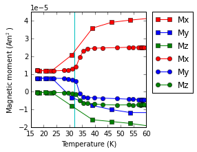

```python
plt.figure(figsize=(3,3),dpi=160)
plt.plot(pyrrhotite_data_series5['Meas_T[K]'][:52],
         pyrrhotite_data_series5['Mx_bsub[Am2]'][:52],
         'rs-', label='Mx')
plt.plot(pyrrhotite_data_series5['Meas_T[K]'][:52],
         pyrrhotite_data_series5['My_bsub[Am2]'][:52],
         'bs-', label='My')
plt.plot(pyrrhotite_data_series5['Meas_T[K]'][:52],
         pyrrhotite_data_series5['Mz_bsub[Am2]'][:52],
         'gs-', label='Mz')
plt.plot(pyrrhotite_data_series5['Meas_T[K]'][52:],
         pyrrhotite_data_series5['Mx_bsub[Am2]'][52:],
         'ro-', label='Mx')
plt.plot(pyrrhotite_data_series5['Meas_T[K]'][52:],
         pyrrhotite_data_series5['My_bsub[Am2]'][52:],
         'bo-', label='My')
plt.plot(pyrrhotite_data_series5['Meas_T[K]'][52:],
         pyrrhotite_data_series5['Mz_bsub[Am2]'][52:],
         'go-', label='Mz')
plt.vlines(32, -2e-5,4.5e-5, colors='c')
plt.xlim(15,60)
plt.ylim(-2e-5,4.5e-5)
plt.ticklabel_format(style='sci', scilimits=(0,0), axis='y')
plt.ylabel('Magnetic moment (Am$^2$)')
plt.xlabel('Temperature (K)')
plt.legend(bbox_to_anchor=(1.05, 1), loc=2, borderaxespad=0.)
#plt.title('Series 5 experiment (background corrected)')
plt.savefig('code_output/pyrrhotite_detail.pdf')
plt.show()
```

In the above plot, the cooling rate is significantly faster than the warming rate. As a result: (a) cooling measurements are widely spaced and (b) the sample is probably not in thermal equilibrium while cooling through the Besnus transition resulting in apparent hysteresis.

## Equal area plots

The directional data for these experiments is quite interesting. The pulse magnetizations were applied in different directions, but in each case the magnetization itself was acquired in the basal plane of the crystal.

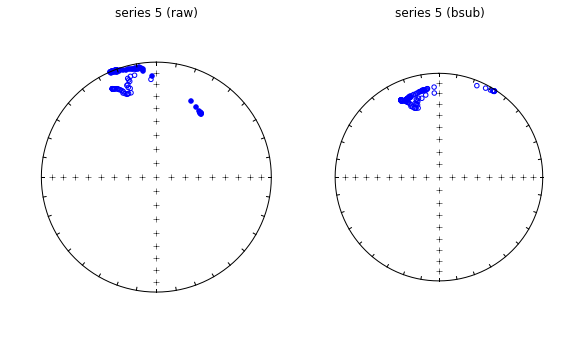

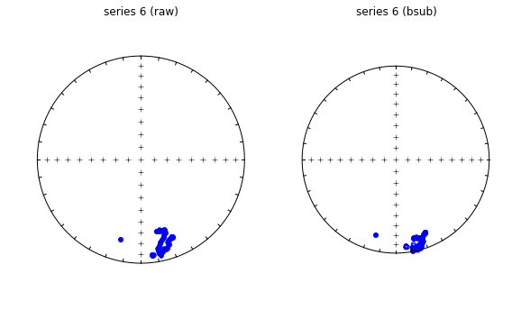

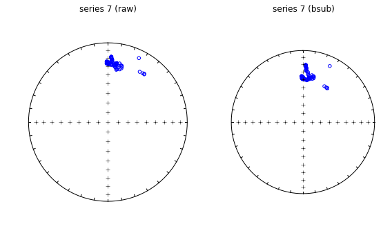

```python
series5_cart=[]
for n in range(len(pyrrhotite_data_series5)):
    series5_cart.append([pyrrhotite_data_series5['Mx[Am2]'][n],
                                    pyrrhotite_data_series5['My[Am2]'][n],
                                    pyrrhotite_data_series5['Mz[Am2]'][n]])
series5_cart_bsub=[]
for n in range(len(pyrrhotite_data_series5)):
    series5_cart_bsub.append([pyrrhotite_data_series5['Mx_bsub[Am2]'][n],
                                    pyrrhotite_data_series5['My_bsub[Am2]'][n],
                                    pyrrhotite_data_series5['Mz_bsub[Am2]'][n]])

series5_DI=pmag.cart2dir(series5_cart)
series5_DI_bsub=pmag.cart2dir(series5_cart_bsub)

fignum=1
fig=plt.figure(figsize=(8,5),dpi=160)
plt.subplot(121)
pmagplotlib.plotNET(fignum)
IPmag.iplotDI(series5_DI,'b')
plt.title('series 5 (raw)')

plt.subplot(122)
pmagplotlib.plotNET(fignum)
IPmag.iplotDI(series5_DI_bsub,'b')
plt.title('series 5 (bsub)')
plt.show()

series6_cart=[]
for n in range(len(pyrrhotite_data_series6)):
    series6_cart.append([pyrrhotite_data_series6['Mx[Am2]'][n],
                                    pyrrhotite_data_series6['My[Am2]'][n],
                                    pyrrhotite_data_series6['Mz[Am2]'][n]])
series6_cart_bsub=[]
for n in range(len(pyrrhotite_data_series6)):
    series6_cart_bsub.append([pyrrhotite_data_series6['Mx_bsub[Am2]'][n],
                                    pyrrhotite_data_series6['My_bsub[Am2]'][n],
                                    pyrrhotite_data_series6['Mz_bsub[Am2]'][n]])

series6_DI=pmag.cart2dir(series6_cart)
series6_DI_bsub=pmag.cart2dir(series6_cart_bsub)

fignum=2
fig=plt.figure(figsize=(8,5),dpi=160)
plt.subplot(121)
pmagplotlib.plotNET(fignum)
IPmag.iplotDI(series6_DI,'b')
plt.title('series 6 (raw)')

plt.subplot(122)
pmagplotlib.plotNET(fignum)
IPmag.iplotDI(series6_DI_bsub,'b')
plt.title('series 6 (bsub)')
plt.show()

series7_cart=[]
for n in range(len(pyrrhotite_data_series7)):
    series7_cart.append([pyrrhotite_data_series7['Mx[Am2]'][n],
                                    pyrrhotite_data_series7['My[Am2]'][n],
                                    pyrrhotite_data_series7['Mz[Am2]'][n]])

series7_cart_bsub=[]
for n in range(len(pyrrhotite_data_series7)):
    series7_cart_bsub.append([pyrrhotite_data_series7['Mx_bsub[Am2]'][n],
                                    pyrrhotite_data_series7['My_bsub[Am2]'][n],
                                    pyrrhotite_data_series7['Mz_bsub[Am2]'][n]])

series7_DI=pmag.cart2dir(series7_cart)
series7_DI_bsub=pmag.cart2dir(series7_cart_bsub)

fignum=3
fig=plt.figure(figsize=(8,5),dpi=160)
plt.subplot(121)
pmagplotlib.plotNET(fignum)
IPmag.iplotDI(series7_DI,'b')
plt.title('series 7 (raw)')

plt.subplot(122)
pmagplotlib.plotNET(fignum)
IPmag.iplotDI(series7_DI_bsub,'b')
plt.title('series 7 (bsub)')
plt.show()
```

For the figure in the manuscript, we presented the background-corrected data upon cooling for each experiment. The code below generates the equal area plots for that figure.

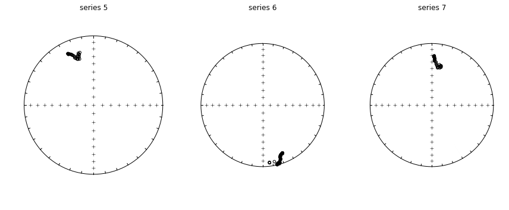

```python
plt.figure(figsize=(12,5),dpi=160)

plt.subplot(131)
pmagplotlib.plotNET(fignum)
IPmag.iplotDI(series5_DI_bsub[1:45],'k')
#just plotting the points during cooling
plt.title('series 5')

plt.subplot(132)
pmagplotlib.plotNET(fignum)
IPmag.iplotDI(series6_DI_bsub[4:56],'k')
#just plotting the points during cooling
plt.title('series 6')

plt.subplot(133)
pmagplotlib.plotNET(fignum)
IPmag.iplotDI(series7_DI_bsub[1:50],'k')
plt.title('series 7')

plt.savefig('code_output/pyrrhotite_equal_area.pdf')
plt.show()
```

# Umkondo Large Igneous Province sill experiments

## Blank probe runs

### Cold Finger Blank run on July 14, 2013

```python
blank1_data_cooling = pd.read_table('../Data/Umkondo/Blank/20130714_blank_cooling.txt')
blank1_data_warming = pd.read_table('../Data/Umkondo/Blank/20130714_blank_warming.txt')
blank1_data_cooling.head()
```

|  | measurement_T[K] | Mx[Am2] | My[Am2] | Mz[Am2] | M_N[Am2] | moment[Am2] |
| --- | --- | --- | --- | --- | --- | --- |
| 0 | 18.34 | -1.339330e-08 | 6.227380e-09 | -6.973380e-09 | -1.339330e-08 | 1.633370e-08 |
| 1 | 26.43 | -2.113220e-08 | 2.720220e-08 | -9.012280e-09 | -2.113220e-08 | 3.560550e-08 |
| 2 | 32.02 | -2.133780e-08 | 3.355980e-08 | -8.730760e-09 | -2.133780e-08 | 4.071600e-08 |
| 3 | 37.88 | -2.063060e-08 | 3.554850e-08 | -8.082560e-09 | -2.063060e-08 | 4.188850e-08 |
| 4 | 42.43 | -1.917700e-08 | 3.565210e-08 | -7.594180e-09 | -1.917700e-08 | 4.118860e-08 |

### Cold Finger Blank run on July 24, 2013

Import the blank run data into dataframes.

```python
blank2_data_cooling = pd.read_table('../Data/Umkondo/Blank/20130724_blank_cooling.txt')
blank2_data_warming = pd.read_table('../Data/Umkondo/Blank/20130724_blank_warming.txt')
blank2_data_warming.tail()
```

|  | measurement_T[K] | Mx[Am2] | My[Am2] | Mz[Am2] | moment[Am2] |
| --- | --- | --- | --- | --- | --- |
| 240 | 284.97 | -2.893900e-09 | 4.405760e-09 | -2.202820e-09 | 5.712950e-09 |
| 241 | 285.97 | -2.974400e-09 | 4.076580e-09 | -2.199280e-09 | 5.504760e-09 |
| 242 | 286.94 | -3.071310e-09 | 4.289740e-09 | -2.199440e-09 | 5.715980e-09 |
| 243 | 287.60 | -2.690500e-09 | 4.263650e-09 | -2.193600e-09 | 5.498130e-09 |
| 244 | 287.61 | -3.253950e-09 | 4.218480e-09 | -2.131440e-09 | 5.738190e-09 |

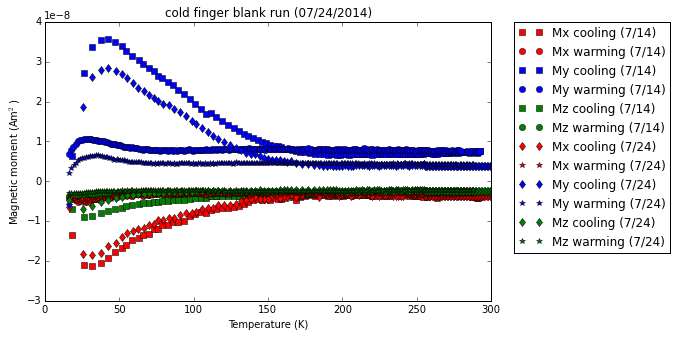

```python
plt.figure(figsize=(8,5),dpi=300)
plt.plot(blank1_data_cooling['measurement_T[K]'], blank1_data_cooling['Mx[Am2]'], 'rs',
         label='Mx cooling (7/14)')
plt.plot(blank1_data_warming['measurement_T[K]'], blank1_data_warming['Mx[Am2]'], 'ro',
         label='Mx warming (7/14)')
plt.plot(blank1_data_cooling['measurement_T[K]'], blank1_data_cooling['My[Am2]'], 'bs',
         label='My cooling (7/14)')
plt.plot(blank1_data_warming['measurement_T[K]'], blank1_data_warming['My[Am2]'], 'bo',
         label='My warming (7/14)')
plt.plot(blank1_data_cooling['measurement_T[K]'], blank1_data_cooling['Mz[Am2]'], 'gs',
         label='Mz cooling (7/14)')
plt.plot(blank1_data_warming['measurement_T[K]'], blank1_data_warming['Mz[Am2]'], 'go',
         label='Mz warming (7/14)')
plt.plot(blank2_data_cooling['measurement_T[K]'], blank2_data_cooling['Mx[Am2]'], 'rd',
         label='Mx cooling (7/24)')
plt.plot(blank2_data_warming['measurement_T[K]'], blank2_data_warming['Mx[Am2]'], 'r*',
         label='Mx warming (7/24)')
plt.plot(blank2_data_cooling['measurement_T[K]'], blank2_data_cooling['My[Am2]'], 'bd',
         label='My cooling (7/24)')
plt.plot(blank2_data_warming['measurement_T[K]'], blank2_data_warming['My[Am2]'], 'b*',
         label='My warming (7/24)')
plt.plot(blank2_data_cooling['measurement_T[K]'], blank2_data_cooling['Mz[Am2]'], 'gd',
         label='Mz cooling (7/24)')
plt.plot(blank2_data_warming['measurement_T[K]'], blank2_data_warming['Mz[Am2]'], 'g*',
         label='Mz warming (7/24)')

plt.ylabel('Magnetic moment (Am$^2$)')
plt.xlabel('Temperature (K)')
plt.legend(bbox_to_anchor=(1.05, 1), loc=2, borderaxespad=0.)
plt.title('cold finger blank run (07/24/2014)')
plt.show()
```

The origin of this signal from the sample holder apparatus is currently unknown and will be investigated further in the future. The signal seems to remain broadly similar through repeated thermal cycling (compare the July 14, 2013 data to the July 24, 2013 data) so we will take the approach of subtracting the holder signal from the sample data. To do this holder subtraction, it is necessary to interpolate the holder signal at the temperatures for which sample data are collected. Here is an example of the spline interpolation of these data that we will use for this purpose. This spline interpolation is the one that is used in the background_sub() function defined above.

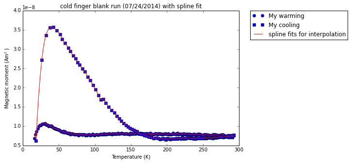

```python
x = blank1_data_warming['measurement_T[K]']
y = blank1_data_warming['My[Am2]']
spline = interpolate.splrep(x,y,s=0)
xnew = np.linspace(blank1_data_warming['measurement_T[K]'].min(),
                   blank1_data_warming['measurement_T[K]'].max()-1, 300)
ynew = interpolate.splev(xnew,spline,der=0)

plt.figure(num=fignum,figsize=(8,5),dpi=300)
plt.plot(x, y, 'bo',
         label='My warming')
plt.plot(xnew,ynew, 'r-')

#For the interpolate function to work the x values (temperature) need to be ascending.
#The blank1_data_cooling can be sorted so that temperatures are ascending
blank1_data_cooling = blank1_data_cooling.sort(['measurement_T[K]'])

x = blank1_data_cooling['measurement_T[K]']
y = blank1_data_cooling['My[Am2]']
tck = interpolate.splrep(x,y,s=0)
xnew = np.linspace(blank1_data_cooling['measurement_T[K]'].min(),
                   blank1_data_cooling['measurement_T[K]'].max(), 300)
ynew = interpolate.splev(xnew,tck,der=0)

plt.plot(x, y, 'bs',
         label='My cooling')
plt.plot(xnew,ynew, 'r-',label='spline fits for interpolation')
plt.ylabel('Magnetic moment (Am$^2$)')
plt.xlabel('Temperature (K)')
plt.legend(bbox_to_anchor=(1.05, 1), loc=2, borderaxespad=0.)
plt.title('cold finger blank run (07/24/2014) with spline fit')
plt.show()
```